# **Project-Statistics in Business Analytics(OPIM-5603)**

## Group Members

- Pranaydeep Khare
- Priya Tomar
- Vikram Krishnareddy

### Overview

In this project, we aim to predict the performance of golfers based on historical performance data using machine learning algorithms. The goal is to build 2 models, one that predicts the number of strokes a golfer will take in a round, taking into account various features like driving distance, accuracy, and other relevant statistics. And another to predict which players land in the top 20 in any round.

### 1. Data sources and preparation process.

#### 1.1 Data sources

1. **pga_historical_raw_data**
   - Data provided had golf performances for each round played in a tournament.
   - Data was unique at a dg_id (Player) x year x event_id (Tournament) x round_num (Round Number) level.
2. **golf_events_sorted** - Pulled from internet and collated manually.
   - The event_id is not ordered chronologically. i.e event_id=500 could happen before event_id=10.
   - The golf_events_sorted dataset has a column tournament_order unique at a year x event_id level ordering the tournaments chronologically.
3. **weatherdata** - Pulled from the internet based on Tournament Location and Tour Dates.
   - Weather data for each tournament providing context on Temperature, Humidity, Wind Speed.
   - Also providing info on Sunny, Cloudy, Foggy days.
4. **course_data_extra** - Pulled from the internet and collated manually.
   - Contextual data about the course like type of grass on Greens and Fairway.
   - Fairway Acres amounts, Greens Acres amounts.
   - Slope and course_ratings.

#### 1.2 Preparation process & Feature Engineering

1. **Common Data Prep**:
   - Create Row_id column to give the table a primary key (for data sanity purposes)
   - Transform and Extract Time data(Hour of Tee Time)
2. **Player Statistics**: Past Performances will be used as indicators to predict what will happen in future tournaments. Various past performance include:
   - Previous Round Performances.
   - Last Tournament Same Round Performance.
   - Last 3 Rounds Rolling Avg performances.
   - Last 5 Rounds Rolling Avg performances.
   - Last Tournament performance
   - Last 3 Tournaments Avg performance.
   - Last 5 Tournaments Avg performance.
   - Last 10 Tournaments Avg performance.
   - Year Till Date Number of tournaments played.
3. **Weather Data Clean Up**
   - Remove '°F' from Temperature Column and keep temp value.
   - Remove 'mph' from windspeed Column and keep windspeed value.
   - Creating a context matrix base on weather notes(Sunny,Cloudy, Foggy, Humid, Dry, Cool, Windy)
4. **Combination of player's past performance x Current Weather Conditions**
   - Proximity x SG_PUTT
   - Temp x SG Putt
   - Wind x Distance
   - Humidity x Proxmity
5. **Course Context**
   - Adding Categorical Data encoding for grass type on Greens and Fairway.

### 2. Model-building steps including feature selection and engineering & Validating the results

#### **2.1 Linear Regression**

**2.2 Logistic Regression**

### 4. Final predictions and model comparisons.

4.1 Linear Regression

4.2 Logistic Regression

# ---------------------------------------------------------------------------------------------------------------

# Importing Libraries

```python
# Data wrangling and manipulation
import pandas as pd
import numpy as np
import duckdb
from fuzzywuzzy import fuzz

# Visualization
import matplotlib.pyplot as plt
import seaborn as sns

# Model training
from sklearn.ensemble import HistGradientBoostingRegressor, HistGradientBoostingClassifier
from sklearn.linear_model import LogisticRegression
from sklearn.linear_model import LinearRegression

# Data preprocessing
from sklearn.preprocessing import StandardScaler
from sklearn.model_selection import train_test_split, GridSearchCV

# Model evaluation
from sklearn.metrics import (
    mean_absolute_error,
    mean_squared_error,
    r2_score,
    accuracy_score,
    precision_score,
    recall_score,
    f1_score,
    roc_auc_score,
    confusion_matrix,
    classification_report,
    log_loss,
    roc_curve
)

# Statsmodels
import statsmodels.api as sm
```

```python
# Adjusting Table Viewing Settings
pd.set_option('display.max_rows', 500)
pd.set_option('display.max_columns', 500)
pd.set_option('display.max_colwidth', None)
```

# Loading Datasets

```python
# Player Data
df=pd.read_csv('pga_historical_raw_data.csv')
# Clean mapping
tournament_rankings=pd.read_csv('golf_events_sorted.csv')
# Weather Conditions Context
weather_data=pd.read_excel('weatherdata.xlsx')
# Course Contexts
course2=pd.read_excel('course_data_extra.xlsx')
```

```python
# Display original shape
print("pga_historical_raw_data shape:", df.shape)
print("golf_events_sorted shape:", tournament_rankings.shape)
print("weather_data shape:", weather_data.shape)
print("course_data_extra shape:", course2.shape)
```

```
pga_historical_raw_data shape: (125469, 32)
golf_events_sorted shape: (322, 4)
weather_data shape: (336, 8)
course_data_extra shape: (359, 14)
```

### Checking Distribution of Round Score

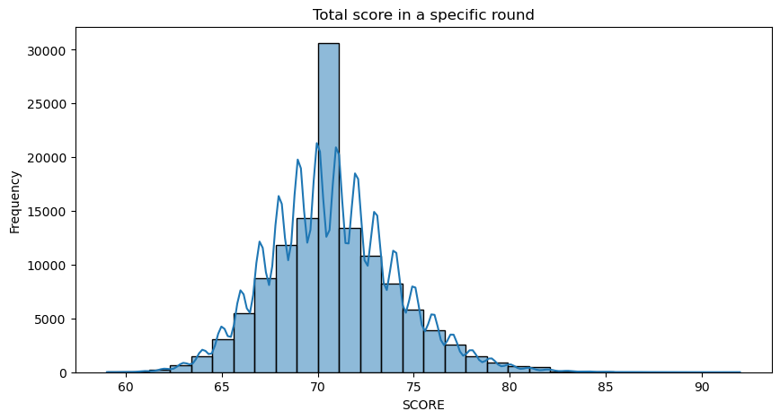

```python
plt.figure(figsize=(10,5))
sns.histplot(df['round_score'], kde=True, bins=30)
plt.title('Total score in a specific round')
plt.xlabel('SCORE')
plt.ylabel('Frequency')
plt.show()
```

# Data Clean Up and Preparation

##### Extracting Hour from TeeTime Column

```python
# Step 1: Convert teetime to datetime.time
df['teetime_parsed'] = pd.to_datetime(df['teetime'], format='%I:%M%p').dt.time

# Step 2: Extract hour from teetime
df['teetime_hour'] = pd.to_datetime(df['teetime'], format='%I:%M%p').dt.hour

# Optional: Preview
print(df[['teetime', 'teetime_parsed', 'teetime_hour']].head())
```

```
  teetime teetime_parsed  teetime_hour
0  1:00pm       13:00:00            13
1  7:50am       07:50:00             7
2  5:40pm       17:40:00            17
3  1:12pm       13:12:00            13
4  7:20am       07:20:00             7
```

```python
# Dropping Rows with null
dataset=df.dropna(subset=['round_score'])
dataset.shape
```

```
(125009, 34)
```

##### Adding Tournament Order

```python
# tournament_rankings sample
tournament_rankings.head(4)
```

|  | event_name | year | New Date | tournament_order |
| --- | --- | --- | --- | --- |
| 0 | SBS Tournament of Champions | 2017 | 05-01-2017 | 1 |
| 1 | Sony Open in Hawaii | 2017 | 12-01-2017 | 2 |
| 2 | CareerBuilder Challenge | 2017 | 19-01-2017 | 3 |
| 3 | Farmers Insurance Open | 2017 | 26-01-2017 | 4 |

```python
# Joining Chronological Tournament Order
dataset=dataset.merge(tournament_rankings,how='left',on=['year','event_name'])
print("Tournament Order Table Shape: ",tournament_rankings.shape)
print("Dataset Integrity Check: ",dataset.shape)
```

```
Tournament Order Table Shape:  (322, 4)
Dataset Integrity Check:  (125009, 36)
```

##### Adding Row Identifier

```python
# Step 1: Sort by your required keys
dataset = dataset.sort_values(by=['year', 'tournament_order', 'event_id', 'dg_id', 'round_num']).reset_index(drop=True)

# Step 2: Add a row_id column
dataset['row_id'] = range(1, len(dataset) + 1)
```

##### One Encoding round_num

```python
# Assuming 'dataset' is your original DataFrame
one_hot = pd.get_dummies(dataset['round_num'], prefix='round')

# Concatenate one-hot encoded columns back to the original dataset
dataset = pd.concat([dataset, one_hot], axis=1)
```

##### External Data for Weather Conditions

```python
# weather_data sample
weather_data.head(4)
```

|  | Tournament | Year | Start Date | Location | Avg Temp (°F) | Humidity (%) | Wind (mph) | Notes |
| --- | --- | --- | --- | --- | --- | --- | --- | --- |
| 0 | Sentry Tournament of Champions | 2020 | 2025-01-02 00:00:00 | Kapalua, Maui, Hawaii | 78°F | 0.70 | 15 mph | Warm, breezy (Maui) |
| 1 | Sony Open in Hawaii | 2020 | 2025-01-09 00:00:00 | Honolulu, Hawaii | 77°F | 0.72 | 12 mph | Humid, occasional showers |
| 2 | The American Express | 2020 | 2025-01-16 00:00:00 | La Quinta, California | 72°F | 0.40 | 8 mph | Dry desert conditions |
| 3 | Farmers Insurance Open | 2020 | 2025-01-23 00:00:00 | San Diego, California | 65°F | 0.55 | 10 mph | Cool coastal breezes |

```python
# Defining "Fuzzy Word" Join as Tournament Names may not exactly match
def fuzzy_left_join_best_match(
    df1,
    df2,
    on_exact_df1,
    on_exact_df2,
    on_fuzzy_df1,
    on_fuzzy_df2,
    threshold=75,
    return_score=False
):
    result_rows = []

    for _, row1 in df1.iterrows():
        # Step 1: Filter df2 by exact key
        exact_val = row1[on_exact_df1]
        df2_subset = df2[df2[on_exact_df2] == exact_val]

        if df2_subset.empty:
            # No match found; return row1 with NaNs for df2
            merged = row1.to_dict()
            for col in df2.columns:
                if col not in merged:
                    merged[col] = None
            if return_score:
                merged["match_score"] = None
            result_rows.append(merged)
            continue

        # Step 2: Fuzzy match within filtered subset
        match_results = [
            (idx, val, fuzz.token_sort_ratio(str(row1[on_fuzzy_df1]), str(val)))
            for idx, val in zip(df2_subset.index, df2_subset[on_fuzzy_df2])
        ]

        best_idx, best_val, best_score = max(match_results, key=lambda x: x[2])

        if best_score >= threshold:
            row2 = df2_subset.loc[best_idx]
            merged = {**row1.to_dict(), **row2.to_dict()}
            if return_score:
                merged["match_score"] = best_score
        else:
            # No sufficiently good match
            merged = row1.to_dict()
            for col in df2.columns:
                if col not in merged:
                    merged[col] = None
            if return_score:
                merged["match_score"] = best_score

        result_rows.append(merged)

    return pd.DataFrame(result_rows)
```

```python
dataset = fuzzy_left_join_best_match(
    dataset,weather_data,
    on_exact_df1='year',
    on_exact_df2='Year',
    on_fuzzy_df1='event_name',
    on_fuzzy_df2='Tournament',
    threshold=50,
    return_score=True
)
```

```python
print("Dataset Integrity Check: ",dataset.shape)
```

```
Dataset Integrity Check:  (125009, 50)
```

##### Single Round Lag

The SQL query calculates the previous round's statistics for various metrics (e.g., score, tee time, and performance) using the LAG window function, partitioned by player (dg_id) and ordered by tournament details. The result is stored in a DataFrame, and its shape (number of rows and columns) is displayed using one_round_lag.shape.

```python
# Your clean SQL query in triple quotes
query = """
    SELECT
        row_id,
        tournament_order,
        year,
        event_id,
        dg_id,
        round_num,
        round_score,
        teetime_hour,
        lag(round_score, 1) OVER (PARTITION BY dg_id ORDER BY year, tournament_order, round_num) AS last_score,
        lag(teetime_hour, 1) OVER (PARTITION BY dg_id ORDER BY year, tournament_order, round_num) AS teetime_hour_score,
        lag(sg_putt, 1) OVER (PARTITION BY dg_id ORDER BY year, tournament_order, round_num) AS last_sg_putt,
        lag(sg_arg, 1) OVER (PARTITION BY dg_id ORDER BY year, tournament_order, round_num) AS last_sg_arg,
        lag(sg_app, 1) OVER (PARTITION BY dg_id ORDER BY year, tournament_order, round_num) AS last_sg_app,
        lag(sg_ott, 1) OVER (PARTITION BY dg_id ORDER BY year, tournament_order, round_num) AS last_sg_ott,
        lag(sg_t2g, 1) OVER (PARTITION BY dg_id ORDER BY year, tournament_order, round_num) AS last_sg_t2g,
        lag(sg_total, 1) OVER (PARTITION BY dg_id ORDER BY year, tournament_order, round_num) AS last_sg_total,
        lag(driving_dist, 1) OVER (PARTITION BY dg_id ORDER BY year, tournament_order, round_num) AS last_driving_dist,
        lag(driving_acc, 1) OVER (PARTITION BY dg_id ORDER BY year, tournament_order, round_num) AS last_driving_acc,
        lag(gir, 1) OVER (PARTITION BY dg_id ORDER BY year, tournament_order, round_num) AS last_gir,
        lag(scrambling, 1) OVER (PARTITION BY dg_id ORDER BY year, tournament_order, round_num) AS last_scrambling,
        lag(prox_rgh, 1) OVER (PARTITION BY dg_id ORDER BY year, tournament_order, round_num) AS last_prox_rgh,
        lag(prox_fw, 1) OVER (PARTITION BY dg_id ORDER BY year, tournament_order, round_num) AS last_prox_fw,
        lag(great_shots, 1) OVER (PARTITION BY dg_id ORDER BY year, tournament_order, round_num) AS last_great_shots,
        lag(poor_shots, 1) OVER (PARTITION BY dg_id ORDER BY year, tournament_order, round_num) AS last_poor_shots
    FROM
        dataset
"""

# Run the query using DuckDB
one_round_lag = duckdb.query(query).to_df()

# Display the result
print("one_round_lag shape",one_round_lag.shape)
```

```
one_round_lag shape (125009, 24)
```

```python
dataset=dataset.merge(one_round_lag,how='left',on='row_id',suffixes=('','_one_round_lag')).sort_values(by='row_id')
print("Dataset Integrity Check: ",dataset.shape)
```

```
Dataset Integrity Check:  (125009, 73)
```

##### Last Tournament Same Round Values - ltrv

The SQL query calculates previous round statistics for various metrics using the LAG function, partitioned by dg_id and round_num, and ordered by year and tournament_order. After running the query, redundant columns are dropped, leaving only the previous round's values in the resulting DataFrame lesr.

```python
query = """
SELECT
    row_id,
    year,
    tournament_order,
    event_id,
    dg_id,
    round_num,
    round_score,
    teetime_hour,
    LAG(round_score, 1) OVER (PARTITION BY dg_id, round_num ORDER BY year, tournament_order, round_num) AS score_lesr,
    LAG(teetime_hour, 1) OVER (PARTITION BY dg_id, round_num ORDER BY year, tournament_order, round_num) AS teetime_hour_lesr,
    LAG(sg_putt, 1) OVER (PARTITION BY dg_id, round_num ORDER BY year, tournament_order, round_num) AS sg_putt_lesr,
    LAG(sg_arg, 1) OVER (PARTITION BY dg_id, round_num ORDER BY year, tournament_order, round_num) AS sg_arg_lesr,
    LAG(sg_app, 1) OVER (PARTITION BY dg_id, round_num ORDER BY year, tournament_order, round_num) AS sg_app_lesr,
    LAG(sg_ott, 1) OVER (PARTITION BY dg_id, round_num ORDER BY year, tournament_order, round_num) AS sg_ott_lesr,
    LAG(sg_t2g, 1) OVER (PARTITION BY dg_id, round_num ORDER BY year, tournament_order, round_num) AS sg_t2g_lesr,
    LAG(sg_total, 1) OVER (PARTITION BY dg_id, round_num ORDER BY year, tournament_order, round_num) AS sg_total_lesr,
    LAG(driving_dist, 1) OVER (PARTITION BY dg_id, round_num ORDER BY year, tournament_order, round_num) AS driving_dist_lesr,
    LAG(driving_acc, 1) OVER (PARTITION BY dg_id, round_num ORDER BY year, tournament_order, round_num) AS driving_acc_lesr,
    LAG(gir, 1) OVER (PARTITION BY dg_id, round_num ORDER BY year, tournament_order, round_num) AS gir_lesr,
    LAG(scrambling, 1) OVER (PARTITION BY dg_id, round_num ORDER BY year, tournament_order, round_num) AS scrambling_lesr,
    LAG(prox_rgh, 1) OVER (PARTITION BY dg_id, round_num ORDER BY year, tournament_order, round_num) AS prox_rgh_lesr,
    LAG(prox_fw, 1) OVER (PARTITION BY dg_id, round_num ORDER BY year, tournament_order, round_num) AS prox_fw_lesr,
    LAG(great_shots, 1) OVER (PARTITION BY dg_id, round_num ORDER BY year, tournament_order, round_num) AS great_shots_lesr,
    LAG(poor_shots, 1) OVER (PARTITION BY dg_id, round_num ORDER BY year, tournament_order, round_num) AS poor_shots_lesr
FROM
    dataset
"""

# Run the query using DuckDB
lesr = duckdb.query(query).to_df()

# Drop redundant columns
lesr = lesr.drop(['year', 'event_id', 'dg_id', 'round_num', 'round_score', 'teetime_hour'], axis=1)

# Display the result
print("lesr shape",lesr.shape)
```

```
lesr shape (125009, 18)
```

```python
dataset=dataset.merge(lesr,how='left',on='row_id',suffixes=('','_lesr'))
dataset.shape
```

```
(125009, 90)
```

##### Rolling Avg for past 3 round and past 5 rounds

The SQL query calculates the average of various metrics over the last 3 and 5 rounds for each player (dg_id) using the AVG window function. The result is stored in the DataFrame last_3and5_r_avg, which contains the calculated averages for each metric.

```python
query = """
SELECT
    row_id,

    -- Last 3 round averages
    AVG(sg_putt) OVER (PARTITION BY dg_id ORDER BY year, tournament_order, round_num ROWS BETWEEN 3 PRECEDING AND 1 PRECEDING) AS sg_putt_mean_3,
    AVG(sg_arg) OVER (PARTITION BY dg_id ORDER BY year, tournament_order, round_num ROWS BETWEEN 3 PRECEDING AND 1 PRECEDING) AS sg_arg_mean_3,
    AVG(sg_app) OVER (PARTITION BY dg_id ORDER BY year, tournament_order, round_num ROWS BETWEEN 3 PRECEDING AND 1 PRECEDING) AS sg_app_mean_3,
    AVG(sg_ott) OVER (PARTITION BY dg_id ORDER BY year, tournament_order, round_num ROWS BETWEEN 3 PRECEDING AND 1 PRECEDING) AS sg_ott_mean_3,
    AVG(sg_t2g) OVER (PARTITION BY dg_id ORDER BY year, tournament_order, round_num ROWS BETWEEN 3 PRECEDING AND 1 PRECEDING) AS sg_t2g_mean_3,
    AVG(sg_total) OVER (PARTITION BY dg_id ORDER BY year, tournament_order, round_num ROWS BETWEEN 3 PRECEDING AND 1 PRECEDING) AS sg_total_mean_3,
    AVG(driving_dist) OVER (PARTITION BY dg_id ORDER BY year, tournament_order, round_num ROWS BETWEEN 3 PRECEDING AND 1 PRECEDING) AS driving_dist_mean_3,
    AVG(driving_acc) OVER (PARTITION BY dg_id ORDER BY year, tournament_order, round_num ROWS BETWEEN 3 PRECEDING AND 1 PRECEDING) AS driving_acc_mean_3,
    AVG(gir) OVER (PARTITION BY dg_id ORDER BY year, tournament_order, round_num ROWS BETWEEN 3 PRECEDING AND 1 PRECEDING) AS gir_mean_3,
    AVG(scrambling) OVER (PARTITION BY dg_id ORDER BY year, tournament_order, round_num ROWS BETWEEN 3 PRECEDING AND 1 PRECEDING) AS scrambling_mean_3,
    AVG(prox_rgh) OVER (PARTITION BY dg_id ORDER BY year, tournament_order, round_num ROWS BETWEEN 3 PRECEDING AND 1 PRECEDING) AS prox_rgh_mean_3,
    AVG(prox_fw) OVER (PARTITION BY dg_id ORDER BY year, tournament_order, round_num ROWS BETWEEN 3 PRECEDING AND 1 PRECEDING) AS prox_fw_mean_3,
    AVG(great_shots) OVER (PARTITION BY dg_id ORDER BY year, tournament_order, round_num ROWS BETWEEN 3 PRECEDING AND 1 PRECEDING) AS great_shots_mean_3,
    AVG(poor_shots) OVER (PARTITION BY dg_id ORDER BY year, tournament_order, round_num ROWS BETWEEN 3 PRECEDING AND 1 PRECEDING) AS poor_shots_mean_3,
    AVG(round_score) OVER (PARTITION BY dg_id ORDER BY year, tournament_order, round_num ROWS BETWEEN 3 PRECEDING AND 1 PRECEDING) AS round_score_mean_3,

    -- Last 5 round averages
    AVG(sg_putt) OVER (PARTITION BY dg_id ORDER BY year, tournament_order, round_num ROWS BETWEEN 5 PRECEDING AND 1 PRECEDING) AS sg_putt_avg_5,
    AVG(sg_arg) OVER (PARTITION BY dg_id ORDER BY year, tournament_order, round_num ROWS BETWEEN 5 PRECEDING AND 1 PRECEDING) AS sg_arg_avg_5,
    AVG(sg_app) OVER (PARTITION BY dg_id ORDER BY year, tournament_order, round_num ROWS BETWEEN 5 PRECEDING AND 1 PRECEDING) AS sg_app_avg_5,
    AVG(sg_ott) OVER (PARTITION BY dg_id ORDER BY year, tournament_order, round_num ROWS BETWEEN 5 PRECEDING AND 1 PRECEDING) AS sg_ott_avg_5,
    AVG(sg_t2g) OVER (PARTITION BY dg_id ORDER BY year, tournament_order, round_num ROWS BETWEEN 5 PRECEDING AND 1 PRECEDING) AS sg_t2g_avg_5,
    AVG(sg_total) OVER (PARTITION BY dg_id ORDER BY year, tournament_order, round_num ROWS BETWEEN 5 PRECEDING AND 1 PRECEDING) AS sg_total_avg_5,
    AVG(driving_dist) OVER (PARTITION BY dg_id ORDER BY year, tournament_order, round_num ROWS BETWEEN 5 PRECEDING AND 1 PRECEDING) AS driving_dist_avg_5,
    AVG(driving_acc) OVER (PARTITION BY dg_id ORDER BY year, tournament_order, round_num ROWS BETWEEN 5 PRECEDING AND 1 PRECEDING) AS driving_acc_avg_5,
    AVG(gir) OVER (PARTITION BY dg_id ORDER BY year, tournament_order, round_num ROWS BETWEEN 5 PRECEDING AND 1 PRECEDING) AS gir_avg_5,
    AVG(scrambling) OVER (PARTITION BY dg_id ORDER BY year, tournament_order, round_num ROWS BETWEEN 5 PRECEDING AND 1 PRECEDING) AS scrambling_avg_5,
    AVG(prox_rgh) OVER (PARTITION BY dg_id ORDER BY year, tournament_order, round_num ROWS BETWEEN 5 PRECEDING AND 1 PRECEDING) AS prox_rgh_avg_5,
    AVG(prox_fw) OVER (PARTITION BY dg_id ORDER BY year, tournament_order, round_num ROWS BETWEEN 5 PRECEDING AND 1 PRECEDING) AS prox_fw_avg_5,
    AVG(great_shots) OVER (PARTITION BY dg_id ORDER BY year, tournament_order, round_num ROWS BETWEEN 5 PRECEDING AND 1 PRECEDING) AS great_shots_avg_5,
    AVG(poor_shots) OVER (PARTITION BY dg_id ORDER BY year, tournament_order, round_num ROWS BETWEEN 5 PRECEDING AND 1 PRECEDING) AS poor_shots_avg_5,
    AVG(round_score) OVER (PARTITION BY dg_id ORDER BY year, tournament_order, round_num ROWS BETWEEN 5 PRECEDING AND 1 PRECEDING) AS round_score_avg_5

FROM dataset;
"""

# Run the query using DuckDB
last_3and5_r_avg = duckdb.query(query).to_df()

# Display the result
print("last_3and5_r_avg shape: ",last_3and5_r_avg.shape)
```

```
last_3and5_r_avg shape:  (125009, 31)
```

```python
dataset=dataset.merge(last_3and5_r_avg,how='left',on='row_id',suffixes=('','_last_3and5_r_avg'))
dataset.shape
```

```
(125009, 120)
```

##### Last Tournaments(event_id) Avg performance 1, 3, 5, 10

The query calculates rolling averages of various golf statistics (e.g., putting, driving accuracy, etc.) for each player across the last 1, 3, 5, and 10 tournaments. It first aggregates these stats per tournament, then uses window functions to compute the desired averages over preceding tournaments.

```python
query = """
SELECT
    dg_id,
    tournament_order,
    event_id,
    year,
    -- Previous tournament (1 preceding)
    AVG(sg_putt_avg) OVER (PARTITION BY dg_id ORDER BY tournament_order ROWS BETWEEN 1 PRECEDING AND 1 PRECEDING) AS sg_putt_avg_last_1_tour,
    AVG(sg_arg_avg) OVER (PARTITION BY dg_id ORDER BY tournament_order ROWS BETWEEN 1 PRECEDING AND 1 PRECEDING) AS sg_arg_avg_last_1_tour,
    AVG(sg_app_avg) OVER (PARTITION BY dg_id ORDER BY tournament_order ROWS BETWEEN 1 PRECEDING AND 1 PRECEDING) AS sg_app_avg_last_1_tour,
    AVG(sg_ott_avg) OVER (PARTITION BY dg_id ORDER BY tournament_order ROWS BETWEEN 1 PRECEDING AND 1 PRECEDING) AS sg_ott_avg_last_1_tour,
    AVG(sg_t2g_avg) OVER (PARTITION BY dg_id ORDER BY tournament_order ROWS BETWEEN 1 PRECEDING AND 1 PRECEDING) AS sg_t2g_avg_last_1_tour,
    AVG(sg_total_avg) OVER (PARTITION BY dg_id ORDER BY tournament_order ROWS BETWEEN 1 PRECEDING AND 1 PRECEDING) AS sg_total_avg_last_1_tour,
    AVG(driving_dist_avg) OVER (PARTITION BY dg_id ORDER BY tournament_order ROWS BETWEEN 1 PRECEDING AND 1 PRECEDING) AS driving_dist_avg_last_1_tour,
    AVG(driving_acc_avg) OVER (PARTITION BY dg_id ORDER BY tournament_order ROWS BETWEEN 1 PRECEDING AND 1 PRECEDING) AS driving_acc_avg_last_1_tour,
    AVG(gir_avg) OVER (PARTITION BY dg_id ORDER BY tournament_order ROWS BETWEEN 1 PRECEDING AND 1 PRECEDING) AS gir_avg_last_1_tour,
    AVG(scrambling_avg) OVER (PARTITION BY dg_id ORDER BY tournament_order ROWS BETWEEN 1 PRECEDING AND 1 PRECEDING) AS scrambling_avg_last_1_tour,
    AVG(prox_rgh_avg) OVER (PARTITION BY dg_id ORDER BY tournament_order ROWS BETWEEN 1 PRECEDING AND 1 PRECEDING) AS prox_rgh_avg_last_1_tour,
    AVG(prox_fw_avg) OVER (PARTITION BY dg_id ORDER BY tournament_order ROWS BETWEEN 1 PRECEDING AND 1 PRECEDING) AS prox_fw_avg_last_1_tour,
    AVG(great_shots_avg) OVER (PARTITION BY dg_id ORDER BY tournament_order ROWS BETWEEN 1 PRECEDING AND 1 PRECEDING) AS great_shots_avg_last_1_tour,
    AVG(poor_shots_avg) OVER (PARTITION BY dg_id ORDER BY tournament_order ROWS BETWEEN 1 PRECEDING AND 1 PRECEDING) AS poor_shots_avg_last_1_tour,
    AVG(round_score_avg) OVER (PARTITION BY dg_id ORDER BY tournament_order ROWS BETWEEN 1 PRECEDING AND 1 PRECEDING) AS round_score_avg_last_1_tour,

    -- Last 3 tournaments
    AVG(sg_putt_avg) OVER (PARTITION BY dg_id ORDER BY tournament_order ROWS BETWEEN 3 PRECEDING AND 1 PRECEDING) AS sg_putt_avg_last_3_tours,
    AVG(sg_arg_avg) OVER (PARTITION BY dg_id ORDER BY tournament_order ROWS BETWEEN 3 PRECEDING AND 1 PRECEDING) AS sg_arg_avg_last_3_tours,
    AVG(sg_app_avg) OVER (PARTITION BY dg_id ORDER BY tournament_order ROWS BETWEEN 3 PRECEDING AND 1 PRECEDING) AS sg_app_avg_last_3_tours,
    AVG(sg_ott_avg) OVER (PARTITION BY dg_id ORDER BY tournament_order ROWS BETWEEN 3 PRECEDING AND 1 PRECEDING) AS sg_ott_avg_last_3_tours,
    AVG(sg_t2g_avg) OVER (PARTITION BY dg_id ORDER BY tournament_order ROWS BETWEEN 3 PRECEDING AND 1 PRECEDING) AS sg_t2g_avg_last_3_tours,
    AVG(sg_total_avg) OVER (PARTITION BY dg_id ORDER BY tournament_order ROWS BETWEEN 3 PRECEDING AND 1 PRECEDING) AS sg_total_avg_last_3_tours,
    AVG(driving_dist_avg) OVER (PARTITION BY dg_id ORDER BY tournament_order ROWS BETWEEN 3 PRECEDING AND 1 PRECEDING) AS driving_dist_avg_last_3_tours,
    AVG(driving_acc_avg) OVER (PARTITION BY dg_id ORDER BY tournament_order ROWS BETWEEN 3 PRECEDING AND 1 PRECEDING) AS driving_acc_avg_last_3_tours,
    AVG(gir_avg) OVER (PARTITION BY dg_id ORDER BY tournament_order ROWS BETWEEN 3 PRECEDING AND 1 PRECEDING) AS gir_avg_last_3_tours,
    AVG(scrambling_avg) OVER (PARTITION BY dg_id ORDER BY tournament_order ROWS BETWEEN 3 PRECEDING AND 1 PRECEDING) AS scrambling_avg_last_3_tours,
    AVG(prox_rgh_avg) OVER (PARTITION BY dg_id ORDER BY tournament_order ROWS BETWEEN 3 PRECEDING AND 1 PRECEDING) AS prox_rgh_avg_last_3_tours,
    AVG(prox_fw_avg) OVER (PARTITION BY dg_id ORDER BY tournament_order ROWS BETWEEN 3 PRECEDING AND 1 PRECEDING) AS prox_fw_avg_last_3_tours,
    AVG(great_shots_avg) OVER (PARTITION BY dg_id ORDER BY tournament_order ROWS BETWEEN 3 PRECEDING AND 1 PRECEDING) AS great_shots_avg_last_3_tours,
    AVG(poor_shots_avg) OVER (PARTITION BY dg_id ORDER BY tournament_order ROWS BETWEEN 3 PRECEDING AND 1 PRECEDING) AS poor_shots_avg_last_3_tours,
    AVG(round_score_avg) OVER (PARTITION BY dg_id ORDER BY tournament_order ROWS BETWEEN 3 PRECEDING AND 1 PRECEDING) AS round_score_avg_last_3_tours,

    -- Last 5 tournaments
    AVG(sg_putt_avg) OVER (PARTITION BY dg_id ORDER BY tournament_order ROWS BETWEEN 5 PRECEDING AND 1 PRECEDING) AS sg_putt_avg_last_5_tours,
    AVG(sg_arg_avg) OVER (PARTITION BY dg_id ORDER BY tournament_order ROWS BETWEEN 5 PRECEDING AND 1 PRECEDING) AS sg_arg_avg_last_5_tours,
    AVG(sg_app_avg) OVER (PARTITION BY dg_id ORDER BY tournament_order ROWS BETWEEN 5 PRECEDING AND 1 PRECEDING) AS sg_app_avg_last_5_tours,
    AVG(sg_ott_avg) OVER (PARTITION BY dg_id ORDER BY tournament_order ROWS BETWEEN 5 PRECEDING AND 1 PRECEDING) AS sg_ott_avg_last_5_tours,
    AVG(sg_t2g_avg) OVER (PARTITION BY dg_id ORDER BY tournament_order ROWS BETWEEN 5 PRECEDING AND 1 PRECEDING) AS sg_t2g_avg_last_5_tours,
    AVG(sg_total_avg) OVER (PARTITION BY dg_id ORDER BY tournament_order ROWS BETWEEN 5 PRECEDING AND 1 PRECEDING) AS sg_total_avg_last_5_tours,
    AVG(driving_dist_avg) OVER (PARTITION BY dg_id ORDER BY tournament_order ROWS BETWEEN 5 PRECEDING AND 1 PRECEDING) AS driving_dist_avg_last_5_tours,
    AVG(driving_acc_avg) OVER (PARTITION BY dg_id ORDER BY tournament_order ROWS BETWEEN 5 PRECEDING AND 1 PRECEDING) AS driving_acc_avg_last_5_tours,
    AVG(gir_avg) OVER (PARTITION BY dg_id ORDER BY tournament_order ROWS BETWEEN 5 PRECEDING AND 1 PRECEDING) AS gir_avg_last_5_tours,
    AVG(scrambling_avg) OVER (PARTITION BY dg_id ORDER BY tournament_order ROWS BETWEEN 5 PRECEDING AND 1 PRECEDING) AS scrambling_avg_last_5_tours,
    AVG(prox_rgh_avg) OVER (PARTITION BY dg_id ORDER BY tournament_order ROWS BETWEEN 5 PRECEDING AND 1 PRECEDING) AS prox_rgh_avg_last_5_tours,
    AVG(prox_fw_avg) OVER (PARTITION BY dg_id ORDER BY tournament_order ROWS BETWEEN 5 PRECEDING AND 1 PRECEDING) AS prox_fw_avg_last_5_tours,
    AVG(great_shots_avg) OVER (PARTITION BY dg_id ORDER BY tournament_order ROWS BETWEEN 5 PRECEDING AND 1 PRECEDING) AS great_shots_avg_last_5_tours,
    AVG(poor_shots_avg) OVER (PARTITION BY dg_id ORDER BY tournament_order ROWS BETWEEN 5 PRECEDING AND 1 PRECEDING) AS poor_shots_avg_last_5_tours,
    AVG(round_score_avg) OVER (PARTITION BY dg_id ORDER BY tournament_order ROWS BETWEEN 5 PRECEDING AND 1 PRECEDING) AS round_score_avg_last_5_tours,

    -- Last 10 tournaments
    AVG(sg_putt_avg) OVER (PARTITION BY dg_id ORDER BY tournament_order ROWS BETWEEN 10 PRECEDING AND 1 PRECEDING) AS sg_putt_avg_last_10_tours,
    AVG(sg_arg_avg) OVER (PARTITION BY dg_id ORDER BY tournament_order ROWS BETWEEN 10 PRECEDING AND 1 PRECEDING) AS sg_arg_avg_last_10_tours,
    AVG(sg_app_avg) OVER (PARTITION BY dg_id ORDER BY tournament_order ROWS BETWEEN 10 PRECEDING AND 1 PRECEDING) AS sg_app_avg_last_10_tours,
    AVG(sg_ott_avg) OVER (PARTITION BY dg_id ORDER BY tournament_order ROWS BETWEEN 10 PRECEDING AND 1 PRECEDING) AS sg_ott_avg_last_10_tours,
    AVG(sg_t2g_avg) OVER (PARTITION BY dg_id ORDER BY tournament_order ROWS BETWEEN 10 PRECEDING AND 1 PRECEDING) AS sg_t2g_avg_last_10_tours,
    AVG(sg_total_avg) OVER (PARTITION BY dg_id ORDER BY tournament_order ROWS BETWEEN 10 PRECEDING AND 1 PRECEDING) AS sg_total_avg_last_10_tours,
    AVG(driving_dist_avg) OVER (PARTITION BY dg_id ORDER BY tournament_order ROWS BETWEEN 10 PRECEDING AND 1 PRECEDING) AS driving_dist_avg_last_10_tours,
    AVG(driving_acc_avg) OVER (PARTITION BY dg_id ORDER BY tournament_order ROWS BETWEEN 10 PRECEDING AND 1 PRECEDING) AS driving_acc_avg_last_10_tours,
    AVG(gir_avg) OVER (PARTITION BY dg_id ORDER BY tournament_order ROWS BETWEEN 10 PRECEDING AND 1 PRECEDING) AS gir_avg_last_10_tours,
    AVG(scrambling_avg) OVER (PARTITION BY dg_id ORDER BY tournament_order ROWS BETWEEN 10 PRECEDING AND 1 PRECEDING) AS scrambling_avg_last_10_tours,
    AVG(prox_rgh_avg) OVER (PARTITION BY dg_id ORDER BY tournament_order ROWS BETWEEN 10 PRECEDING AND 1 PRECEDING) AS prox_rgh_avg_last_10_tours,
    AVG(prox_fw_avg) OVER (PARTITION BY dg_id ORDER BY tournament_order ROWS BETWEEN 10 PRECEDING AND 1 PRECEDING) AS prox_fw_avg_last_10_tours,
    AVG(great_shots_avg) OVER (PARTITION BY dg_id ORDER BY tournament_order ROWS BETWEEN 10 PRECEDING AND 1 PRECEDING) AS great_shots_avg_last_10_tours,
    AVG(poor_shots_avg) OVER (PARTITION BY dg_id ORDER BY tournament_order ROWS BETWEEN 10 PRECEDING AND 1 PRECEDING) AS poor_shots_avg_last_10_tours,
    AVG(round_score_avg) OVER (PARTITION BY dg_id ORDER BY tournament_order ROWS BETWEEN 10 PRECEDING AND 1 PRECEDING) AS round_score_avg_last_10_tours

FROM (
    SELECT
        dg_id,
        tournament_order,
        year,
        event_id,
        AVG(sg_putt) AS sg_putt_avg,
        AVG(sg_arg) AS sg_arg_avg,
        AVG(sg_app) AS sg_app_avg,
        AVG(sg_ott) AS sg_ott_avg,
        AVG(sg_t2g) AS sg_t2g_avg,
        AVG(sg_total) AS sg_total_avg,
        AVG(driving_dist) AS driving_dist_avg,
        AVG(driving_acc) AS driving_acc_avg,
        AVG(gir) AS gir_avg,
        AVG(scrambling) AS scrambling_avg,
        AVG(prox_rgh) AS prox_rgh_avg,
        AVG(prox_fw) AS prox_fw_avg,
        AVG(great_shots) AS great_shots_avg,
        AVG(poor_shots) AS poor_shots_avg,
        AVG(round_score) AS round_score_avg
    FROM dataset
    GROUP BY dg_id, year, tournament_order,event_id
) AS tournament_summary;
"""

# Run the query
last_tournaments = duckdb.query(query).to_df()

# Display
print("last_tournaments shape: ",last_tournaments.shape)
```

```
last_tournaments shape:  (40184, 64)
```

```python
dataset=dataset.merge(last_tournaments,how='left',on=['dg_id','year','event_id','tournament_order'],suffixes=('','_last_tournament'))
print("Dataset Integrity Check: ",dataset.shape)
```

```
Dataset Integrity Check:  (125009, 180)
```

##### Nth Tournament of the Year

The query calculates the "year-to-date" (YTD) tournament count for each player (dg_id) by assigning a dense rank based on the tournament_order within each year (year). It uses the dense_rank() window function to determine the rank of each tournament within the same year and partitioned by dg_id. The result is a dataset that includes the row_id along with the computed YTD tournament count for each player across different tournaments.

```python
# Your clean SQL query in triple quotes
query = """
SELECT
    row_id,
    dense_rank() OVER (PARTITION BY dg_id, year ORDER BY tournament_order) AS ytd_tournament_counts
FROM dataset;


"""

# Run the query using DuckDB
ytd_nth_tournament = duckdb.query(query).to_df()


# Display
print("ytd_nth_tournament shape: ",ytd_nth_tournament.shape)
```

```
ytd_nth_tournament shape:  (125009, 2)
```

```python
dataset=dataset.merge(ytd_nth_tournament,how='left',on=['row_id'],suffixes=('',''))
print("Dataset Integrity Check: ",dataset.shape)
```

```
Dataset Integrity Check:  (125009, 181)
```

##### Weather Columns Cleanup

The clean_temperature() function extracts the numerical value from a temperature string (e.g., "71°F") or returns NaN for invalid inputs. It is applied to the Avg Temp (°F) column in the dataset to create a new cleaned_temperature column.

```python
# Temperature Column Clean Up
def clean_temperature(temp_str):
  """
  Cleans a temperature string (e.g. "71°F") and extracts the numerical value as a float.
  Handles cases where the input is already a number.

  Args:
    temp_str: The temperature string or number.

  Returns:
    A float representing the temperature, or NaN if the string cannot be parsed.
  """
  try:
    if isinstance(temp_str, (int, float)):
      return float(temp_str)  # Already a number, convert to float
    else:
      temp_str = str(temp_str).replace("°F", "").strip()
      return float(temp_str)
  except (ValueError, TypeError):
    return float('nan')  # Return NaN for invalid input


# Apply the function to create a new column with cleaned temperature values
dataset['cleaned_temperature'] = dataset['Avg Temp (°F)'].apply(clean_temperature)
```

The clean_wind_speed() function extracts the numerical value from wind speed strings (e.g., "10 mph") or returns NaN for invalid inputs. It is applied to the 'Wind (mph)' column in the dataset to create a new 'cleaned_wind_speed' column.

```python
# Windspeed Column Clean Up
def clean_wind_speed(wind_str):
    """
    Cleans a wind speed string (e.g., "10 mph") and extracts the numerical value as a float.

    Args:
        wind_str: The wind speed string.

    Returns:
        A float representing the wind speed, or NaN if the string cannot be parsed.
    """
    try:
        if isinstance(wind_str, (int, float)):
          return float(wind_str)
        else:
          return float(str(wind_str).split()[0])
    except (ValueError, IndexError, AttributeError):
        return float('nan')

# Assuming your DataFrame is named 'weather_df' and the column with wind speed is named 'wind_speed'
# Replace 'wind_speed' with the actual column name if it's different.

# Example usage (assuming 'weather_df' and 'wind_speed' column exist):
# Create a sample DataFrame (replace with your actual DataFrame)
data = {'wind_speed': ['10 mph', '15 mph', '20 mph', 'invalid', 25]}
weather_df = pd.DataFrame(data)

dataset['cleaned_wind_speed'] = dataset['Wind (mph)'].apply(clean_wind_speed)
```

This code creates a weather condition matrix by analyzing weather-related keywords in the "Notes" column. It generates boolean columns for conditions like sunny, raining, foggy, and more based on the presence of these keywords

```python
# Weather Context Categorical Data
notes=dataset[(dataset['year']>=2019)]['Notes'].unique()

# Create a dictionary to store the weather conditions
weather_dict = {
    'notes': notes,
    'sunny': [1 if 'sunny' in note.lower() or 'sun' in note.lower() else 0 for note in notes],
    'raining': [1 if 'rain' in note.lower() or 'showers' in note.lower() or 'storms' in note.lower() else 0 for note in notes],
    'foggy': [1 if 'fog' in note.lower() else 0 for note in notes],
    'humid': [1 if 'humid' in note.lower() or 'sticky' in note.lower() or 'muggy' in note.lower() else 0 for note in notes],
    'breezy': [1 if 'breeze' in note.lower() or 'breezy' in note.lower() or 'windy' in note.lower() else 0 for note in notes],
    'dry': [1 if 'dry' in note.lower() or 'desert' in note.lower() else 0 for note in notes],
    'warm': [1 if 'warm' in note.lower() else 0 for note in notes],
    'hot': [1 if 'hot' in note.lower() else 0 for note in notes],
    'cool': [1 if 'cool' in note.lower() else 0 for note in notes],
    'mild': [1 if 'mild' in note.lower() else 0 for note in notes],
    'coastal': [1 if 'coastal' in note.lower() or 'ocean' in note.lower() or 'marine' in note.lower() else 0 for note in notes],
    'tropical': [1 if 'tropical' in note.lower() else 0 for note in notes]
}


# Create a pandas DataFrame from the dictionary
weather_df = pd.DataFrame(weather_dict)

# Display all columns of the DataFrame
weather_df.head(4)
```

|  | notes | sunny | raining | foggy | humid | breezy | dry | warm | hot | cool | mild | coastal | tropical |
| --- | --- | --- | --- | --- | --- | --- | --- | --- | --- | --- | --- | --- | --- |
| 0 | Breezy, warm | 0 | 0 | 0 | 0 | 1 | 0 | 1 | 0 | 0 | 0 | 0 | 0 |
| 1 | Humid, ocean breezes | 0 | 0 | 0 | 1 | 1 | 0 | 0 | 0 | 0 | 0 | 1 | 0 |
| 2 | Dry desert conditions | 0 | 0 | 0 | 0 | 0 | 1 | 0 | 0 | 0 | 0 | 0 | 0 |
| 3 | Mild coastal air | 0 | 0 | 0 | 0 | 0 | 0 | 0 | 0 | 0 | 1 | 1 | 0 |

```python
dataset=dataset.merge(weather_df,how='left',left_on='Notes',right_on='notes')
print("Dataset Integrity Check: ",dataset.shape)
```

```
Dataset Integrity Check:  (125009, 196)
```

### New Calculated features like:

```
* Weighted Proximity, Weighted Proximity x SG_PUTT
* Temp x SG Putt
* Wind x Distance
* Humidity x Proxmity
```

```python
# Mapping time tags to exact column names in your dataset
time_mappings = {
    'last': {
        'fw': 'last_prox_fw',
        'rgh': 'last_prox_rgh',
        'acc': 'last_driving_acc',
        'sg_putt': 'last_sg_putt'
    },
    'lesr': {
        'fw': 'prox_fw_lesr',
        'rgh': 'prox_rgh_lesr',
        'acc': 'driving_acc_lesr',
        'sg_putt': 'sg_putt_lesr'
    },
    'mean_3': {
        'fw': 'prox_fw_mean_3',
        'rgh': 'prox_rgh_mean_3',
        'acc': 'driving_acc_mean_3',
        'sg_putt': 'sg_putt_mean_3'
    },
    'avg_5': {
        'fw': 'prox_fw_avg_5',
        'rgh': 'prox_rgh_avg_5',
        'acc': 'driving_acc_avg_5',
        'sg_putt': 'sg_putt_avg_5'
    },
    'avg_last_1_tour': {
        'fw': 'prox_fw_avg_last_1_tour',
        'rgh': 'prox_rgh_avg_last_1_tour',
        'acc': 'driving_acc_avg_last_1_tour',
        'sg_putt': 'sg_putt_avg_last_1_tour'
    },
    'avg_last_3_tours': {
        'fw': 'prox_fw_avg_last_3_tours',
        'rgh': 'prox_rgh_avg_last_3_tours',
        'acc': 'driving_acc_avg_last_3_tours',
        'sg_putt': 'sg_putt_avg_last_3_tours'
    },
    'avg_last_5_tours': {
        'fw': 'prox_fw_avg_last_5_tours',
        'rgh': 'prox_rgh_avg_last_5_tours',
        'acc': 'driving_acc_avg_last_5_tours',
        'sg_putt': 'sg_putt_avg_last_5_tours'
    },
    'avg_last_10_tours': {
        'fw': 'prox_fw_avg_last_10_tours',
        'rgh': 'prox_rgh_avg_last_10_tours',
        'acc': 'driving_acc_avg_last_10_tours',
        'sg_putt': 'sg_putt_avg_last_10_tours'
    }
}

# Generate weighted proximity and interaction features
for tag, cols in time_mappings.items():
    fw_col = cols['fw']
    rgh_col = cols['rgh']
    acc_col = cols['acc']
    sg_col = cols['sg_putt']

    weighted_prox_col = f'weighted_proximity_{tag}'
    interaction_col = f'weighted_proximity_x_sg_putt_{tag}'

    dataset[weighted_prox_col] = dataset[acc_col] * dataset[fw_col] + (1 - dataset[acc_col]) * dataset[rgh_col]
    dataset[interaction_col] = dataset[weighted_prox_col] * dataset[sg_col]
```

```python
print("Dataset Integrity Check: ",dataset.shape)
```

```
Dataset Integrity Check:  (125009, 212)
```

```python
# Define the time horizon suffixes
time_horizons = [
    'last',
    'lesr',
    'mean_3',
    'avg_5',
    'avg_last_1_tour',
    'avg_last_3_tours',
    'avg_last_5_tours',
    'avg_last_10_tours'
]

# Loop and create interaction features
for tag in time_horizons:
    # Driving distance
    driving_dist_col = f'driving_dist_{tag}' if tag != 'last' else 'last_driving_dist'

    # SG Putting
    sg_putt_col = f'sg_putt_{tag}' if tag != 'last' else 'last_sg_putt'

    # Weighted proximity
    weighted_prox_col = f'weighted_proximity_{tag}'

    # Interaction features
    dataset[f'wind_x_driving_dist_{tag}'] = dataset['cleaned_wind_speed'] * dataset[driving_dist_col]
    dataset[f'humidity_x_weighted_prox_{tag}'] = dataset['Humidity (%)'] * dataset[weighted_prox_col]
    dataset[f'temp_x_sg_putt_{tag}'] = dataset['cleaned_temperature'] * dataset[sg_putt_col]
```

```python
print("Dataset Integrity Check: ",dataset.shape)
```

```
Dataset Integrity Check:  (125009, 236)
```

##### Course Historic Data

This code applies a mapping to normalize messy or inconsistent course names in the dataset, ensuring that different variations of the same course name are standardized. The course_name_mapping dictionary maps known variations to a consistent name, which is then applied to the course_name column to create a course_name_normalized column

```python
# Standardisaing Course name

# Updated mapping for all known messy names
course_name_mapping = {
    # Bay Hill
    "Arnold Palmer's Bay Hill Club & Lodge": "Bay Hill Club & Lodge",

    # Pebble Beach group
    "Pebble Beach GL": "Pebble Beach Golf Links",
    "Spyglass Hill GC": "Spyglass Hill Golf Course",
    "Spyglass Hill Golf Course": "Spyglass Hill Golf Course",
    "Pebble Beach Golf Links": "Pebble Beach Golf Links",
    "Monterey Peninsula CC": "Monterey Peninsula Country Club",

    # Keene Trace
    "Keene Trace Golf Club": "Keene Trace Golf Club (Champions Course)",

    # Tahoe Mountain Club
    "Old Greenwood Golf Course at Tahoe Mountain Club": "Old Greenwood (Tahoe Mountain Club)",
    "Tahoe Mt. Club (Old Greenwood)": "Old Greenwood (Tahoe Mountain Club)",
    "Tahoe Mountain Club (Old Greenwood)": "Old Greenwood (Tahoe Mountain Club)",

    # Torrey Pines
    "Torrey Pines GC (South)": "Torrey Pines (South)",
    "Torrey Pines (South)": "Torrey Pines (South)",
    "Torrey Pines GC (North)": "Torrey Pines (North)",
    "Torrey Pines (North)": "Torrey Pines (North)",
    "Torrey Pines Golf Course (North Course)": "Torrey Pines (North)",
    "Torrey Pines Golf Course (South Course)": "Torrey Pines (South)",

    # Silverado
    "Silverado Resort and Spa North": "Silverado Resort & Spa (North)",
    "Silverado Resort and Spa (North Course)": "Silverado Resort & Spa (North)",

    # Sea Island
    "Sea Island Resort (Plantation)": "Sea Island Golf Club (Plantation Course)",
    "Sea Island Resort (Seaside)": "Sea Island Golf Club (Seaside Course)",
    "Sea Island GC (Plantation)": "Sea Island Golf Club (Plantation Course)",
    "Sea Island GC (Seaside)": "Sea Island Golf Club (Seaside Course)",
    "Sea Island Golf Club (Plantation)": "Sea Island Golf Club (Plantation Course)",
    "Sea Island Golf Club (Seaside)": "Sea Island Golf Club (Seaside Course)",

    # Riviera
    "Riviera CC": "Riviera Country Club",
    "The Riviera Country Club": "Riviera Country Club",

    # Albany
    "Albany GC": "Albany",
    "Albany, Bahamas": "Albany",

    # Waialae
    "Waialae CC": "Waialae Country Club",

    # Sedgefield
    "Sedgefield CC": "Sedgefield Country Club",

    # Accordia
    "Accordia Golf Narashino CC": "Accordia Golf Narashino Country Club",

    # TPC San Antonio
    "TPC San Antonio (Oaks Course)": "TPC San Antonio - AT&T Oaks",

    # Sawgrass
    "TPC Sawgrass (THE PLAYERS Stadium Course)": "TPC Sawgrass",

    # Coralès
    "Puntacana Resort & Club (Corales Golf Course)": "Corales Golf Club",

    # Houston Golf Club
    "GC of Houston": "Golf Club of Houston",

    # La Quinta
    "La Quinta CC": "La Quinta Country Club",

    # Nine Bridges
    "Nine Bridges": "Club at Nine Bridges",

    # Harbour Town
    "Harbour Town GL": "Harbour Town Golf Links",

    # Muirfield Village
    "Muirfield Village GC": "Muirfield Village Golf Club",

    # East Lake
    "East Lake GC": "East Lake Golf Club",

    # Sheshan International
    "Sheshan International GC": "Sheshan International Golf Club",

    # Club de Golf Chapultepec
    "Club de Golf Chapultepec": "Club de Golf Chapultepec",

    # Congaree
    "Congaree Golf Club": "Congaree Golf Club",

    # El Camaleon
    "El Camaleon GC": "El Camaleon Golf Club",
    "El CamaleÃƒÂ³n Golf Course at Mayakoba": "El Camaleon Golf Club",
}

# Apply normalization
dataset['course_name_normalized'] = dataset['course_name'].apply(lambda x: course_name_mapping.get(x, x))
```

##### AVG Histroric Performances on Courses

This query computes lag values and rolling averages (for the last 1, 3, and 5 years) of various golf metrics, grouped by course and year. The result includes calculated averages for each metric (e.g., round score, driving distance, SG stats) across the specified time horizons.

```python
query = """
SELECT
    t1.course_name AS course_name_normalized,
    t1.year,

    -- Previous year values (lag 1)
    LAG(t1.avg_round_score, 1) OVER (PARTITION BY t1.course_name ORDER BY t1.year) AS last_1_year_round_score_course_avg,
    LAG(t1.avg_sg_putt, 1) OVER (PARTITION BY t1.course_name ORDER BY t1.year) AS last_1_year_sg_putt_course_avg,
    LAG(t1.avg_sg_arg, 1) OVER (PARTITION BY t1.course_name ORDER BY t1.year) AS last_1_year_sg_arg_course_avg,
    LAG(t1.avg_sg_app, 1) OVER (PARTITION BY t1.course_name ORDER BY t1.year) AS last_1_year_sg_app_course_avg,
    LAG(t1.avg_sg_ott, 1) OVER (PARTITION BY t1.course_name ORDER BY t1.year) AS last_1_year_sg_ott_course_avg,
    LAG(t1.avg_sg_t2g, 1) OVER (PARTITION BY t1.course_name ORDER BY t1.year) AS last_1_year_sg_t2g_course_avg,
    LAG(t1.avg_sg_total, 1) OVER (PARTITION BY t1.course_name ORDER BY t1.year) AS last_1_year_sg_total_course_avg,
    LAG(t1.avg_driving_dist, 1) OVER (PARTITION BY t1.course_name ORDER BY t1.year) AS last_1_year_driving_dist_course_avg,
    LAG(t1.avg_driving_acc, 1) OVER (PARTITION BY t1.course_name ORDER BY t1.year) AS last_1_year_driving_acc_course_avg,
    LAG(t1.avg_gir, 1) OVER (PARTITION BY t1.course_name ORDER BY t1.year) AS last_1_year_gir_course_avg,
    LAG(t1.avg_scrambling, 1) OVER (PARTITION BY t1.course_name ORDER BY t1.year) AS last_1_year_scrambling_course_avg,
    LAG(t1.avg_prox_rgh, 1) OVER (PARTITION BY t1.course_name ORDER BY t1.year) AS last_1_year_prox_rgh_course_avg,
    LAG(t1.avg_prox_fw, 1) OVER (PARTITION BY t1.course_name ORDER BY t1.year) AS last_1_year_prox_fw_course_avg,
    LAG(t1.avg_great_shots, 1) OVER (PARTITION BY t1.course_name ORDER BY t1.year) AS last_1_year_great_shots_course_avg,
    LAG(t1.avg_poor_shots, 1) OVER (PARTITION BY t1.course_name ORDER BY t1.year) AS last_1_year_poor_shots_course_avg,

    -- 3-year rolling AVERAGE (strictly past 3 years)
    AVG(t1.avg_round_score) OVER (PARTITION BY t1.course_name ORDER BY t1.year ROWS BETWEEN 3 PRECEDING AND 1 PRECEDING) AS last_3_year_round_score_course_avg,
    AVG(t1.avg_sg_putt) OVER (PARTITION BY t1.course_name ORDER BY t1.year ROWS BETWEEN 3 PRECEDING AND 1 PRECEDING) AS last_3_year_sg_putt_course_avg,
    AVG(t1.avg_sg_arg) OVER (PARTITION BY t1.course_name ORDER BY t1.year ROWS BETWEEN 3 PRECEDING AND 1 PRECEDING) AS last_3_year_sg_arg_course_avg,
    AVG(t1.avg_sg_app) OVER (PARTITION BY t1.course_name ORDER BY t1.year ROWS BETWEEN 3 PRECEDING AND 1 PRECEDING) AS last_3_year_sg_app_course_avg,
    AVG(t1.avg_sg_ott) OVER (PARTITION BY t1.course_name ORDER BY t1.year ROWS BETWEEN 3 PRECEDING AND 1 PRECEDING) AS last_3_year_sg_ott_course_avg,
    AVG(t1.avg_sg_t2g) OVER (PARTITION BY t1.course_name ORDER BY t1.year ROWS BETWEEN 3 PRECEDING AND 1 PRECEDING) AS last_3_year_sg_t2g_course_avg,
    AVG(t1.avg_sg_total) OVER (PARTITION BY t1.course_name ORDER BY t1.year ROWS BETWEEN 3 PRECEDING AND 1 PRECEDING) AS last_3_year_sg_total_course_avg,
    AVG(t1.avg_driving_dist) OVER (PARTITION BY t1.course_name ORDER BY t1.year ROWS BETWEEN 3 PRECEDING AND 1 PRECEDING) AS last_3_year_driving_dist_course_avg,
    AVG(t1.avg_driving_acc) OVER (PARTITION BY t1.course_name ORDER BY t1.year ROWS BETWEEN 3 PRECEDING AND 1 PRECEDING) AS last_3_year_driving_acc_course_avg,
    AVG(t1.avg_gir) OVER (PARTITION BY t1.course_name ORDER BY t1.year ROWS BETWEEN 3 PRECEDING AND 1 PRECEDING) AS last_3_year_gir_course_avg,
    AVG(t1.avg_scrambling) OVER (PARTITION BY t1.course_name ORDER BY t1.year ROWS BETWEEN 3 PRECEDING AND 1 PRECEDING) AS last_3_year_scrambling_course_avg,
    AVG(t1.avg_prox_rgh) OVER (PARTITION BY t1.course_name ORDER BY t1.year ROWS BETWEEN 3 PRECEDING AND 1 PRECEDING) AS last_3_year_prox_rgh_course_avg,
    AVG(t1.avg_prox_fw) OVER (PARTITION BY t1.course_name ORDER BY t1.year ROWS BETWEEN 3 PRECEDING AND 1 PRECEDING) AS last_3_year_prox_fw_course_avg,
    AVG(t1.avg_great_shots) OVER (PARTITION BY t1.course_name ORDER BY t1.year ROWS BETWEEN 3 PRECEDING AND 1 PRECEDING) AS last_3_year_great_shots_course_avg,
    AVG(t1.avg_poor_shots) OVER (PARTITION BY t1.course_name ORDER BY t1.year ROWS BETWEEN 3 PRECEDING AND 1 PRECEDING) AS last_3_year_poor_shots_course_avg,

    -- 5-year rolling AVERAGE (strictly past 5 years)
    AVG(t1.avg_round_score) OVER (PARTITION BY t1.course_name ORDER BY t1.year ROWS BETWEEN 5 PRECEDING AND 1 PRECEDING) AS last_5_year_round_score_course_avg,
    AVG(t1.avg_sg_putt) OVER (PARTITION BY t1.course_name ORDER BY t1.year ROWS BETWEEN 5 PRECEDING AND 1 PRECEDING) AS last_5_year_sg_putt_course_avg,
    AVG(t1.avg_sg_arg) OVER (PARTITION BY t1.course_name ORDER BY t1.year ROWS BETWEEN 5 PRECEDING AND 1 PRECEDING) AS last_5_year_sg_arg_course_avg,
    AVG(t1.avg_sg_app) OVER (PARTITION BY t1.course_name ORDER BY t1.year ROWS BETWEEN 5 PRECEDING AND 1 PRECEDING) AS last_5_year_sg_app_course_avg,
    AVG(t1.avg_sg_ott) OVER (PARTITION BY t1.course_name ORDER BY t1.year ROWS BETWEEN 5 PRECEDING AND 1 PRECEDING) AS last_5_year_sg_ott_course_avg,
    AVG(t1.avg_sg_t2g) OVER (PARTITION BY t1.course_name ORDER BY t1.year ROWS BETWEEN 5 PRECEDING AND 1 PRECEDING) AS last_5_year_sg_t2g_course_avg,
    AVG(t1.avg_sg_total) OVER (PARTITION BY t1.course_name ORDER BY t1.year ROWS BETWEEN 5 PRECEDING AND 1 PRECEDING) AS last_5_year_sg_total_course_avg,
    AVG(t1.avg_driving_dist) OVER (PARTITION BY t1.course_name ORDER BY t1.year ROWS BETWEEN 5 PRECEDING AND 1 PRECEDING) AS last_5_year_driving_dist_course_avg,
    AVG(t1.avg_driving_acc) OVER (PARTITION BY t1.course_name ORDER BY t1.year ROWS BETWEEN 5 PRECEDING AND 1 PRECEDING) AS last_5_year_driving_acc_course_avg,
    AVG(t1.avg_gir) OVER (PARTITION BY t1.course_name ORDER BY t1.year ROWS BETWEEN 5 PRECEDING AND 1 PRECEDING) AS last_5_year_gir_course_avg,
    AVG(t1.avg_scrambling) OVER (PARTITION BY t1.course_name ORDER BY t1.year ROWS BETWEEN 5 PRECEDING AND 1 PRECEDING) AS last_5_year_scrambling_course_avg,
    AVG(t1.avg_prox_rgh) OVER (PARTITION BY t1.course_name ORDER BY t1.year ROWS BETWEEN 5 PRECEDING AND 1 PRECEDING) AS last_5_year_prox_rgh_course_avg,
    AVG(t1.avg_prox_fw) OVER (PARTITION BY t1.course_name ORDER BY t1.year ROWS BETWEEN 5 PRECEDING AND 1 PRECEDING) AS last_5_year_prox_fw_course_avg,
    AVG(t1.avg_great_shots) OVER (PARTITION BY t1.course_name ORDER BY t1.year ROWS BETWEEN 5 PRECEDING AND 1 PRECEDING) AS last_5_year_great_shots_course_avg,
    AVG(t1.avg_poor_shots) OVER (PARTITION BY t1.course_name ORDER BY t1.year ROWS BETWEEN 5 PRECEDING AND 1 PRECEDING) AS last_5_year_poor_shots_course_avg

FROM (
    SELECT
        course_name_normalized AS course_name,
        year,
        AVG(round_score) AS avg_round_score,
        AVG(sg_putt) AS avg_sg_putt,
        AVG(sg_arg) AS avg_sg_arg,
        AVG(sg_app) AS avg_sg_app,
        AVG(sg_ott) AS avg_sg_ott,
        AVG(sg_t2g) AS avg_sg_t2g,
        AVG(sg_total) AS avg_sg_total,
        AVG(driving_dist) AS avg_driving_dist,
        AVG(driving_acc) AS avg_driving_acc,
        AVG(gir) AS avg_gir,
        AVG(scrambling) AS avg_scrambling,
        AVG(prox_rgh) AS avg_prox_rgh,
        AVG(prox_fw) AS avg_prox_fw,
        AVG(great_shots) AS avg_great_shots,
        AVG(poor_shots) AS avg_poor_shots
    FROM
        dataset
    GROUP BY
        course_name_normalized,
        year
) t1
ORDER BY
    t1.course_name,
    t1.year;
"""

# Run safely
course_data = duckdb.query(query).to_df()
```

```python
dataset=dataset.merge(course_data,how='left',on=['course_name_normalized','year'])
print("Dataset Integrity Check: ",dataset.shape)
```

```
Dataset Integrity Check:  (125009, 282)
```

##### Historic Made Cut %

###### 1. Adding Made Cut Flag for each tournament

```python
# Subset of test table
r1_r2 = dataset[dataset['round_num'].isin([1, 2])]
# Get total score for first 2 rounds
r1_r2_sum = (
    r1_r2.groupby(['year', 'event_id', 'dg_id'])['round_score']
    .sum()
    .reset_index()
    .rename(columns={'round_score': 'r1_r2_total_score'})
)
# Rank players based on R1+R2 total
r1_r2_sum['r1_r2_rank'] = (
    r1_r2_sum.groupby(['year', 'event_id'])['r1_r2_total_score']
    .rank(method='min')
)

# Convert rank to integer
r1_r2_sum['r1_r2_rank'] = r1_r2_sum['r1_r2_rank'].astype(int)
# Made cut flag
r1_r2_sum['made_cut'] = (r1_r2_sum['r1_r2_rank'] <= 65).astype(int)

dataset = dataset.merge(r1_r2_sum[['year', 'event_id', 'dg_id', 'made_cut']], on=['year', 'event_id', 'dg_id'], how='left')
```

###### 2. Getting Historic Made Cut % in the past 10, 20, 50, YTD Tours.

This query calculates rolling averages for the "made cut" metric over various time windows (last 10, 20, 50 tournaments) and for the year-to-date (YTD) performance for each player (identified by dg_id) and event (event_id). The query groups the data by dg_id and computes the averages for each of the specified time horizons.

```python
# Your clean SQL query in triple quotes
query = """
select
    year,
    event_id,
    dg_id,
    --Last 10
    avg(made_cut) over (partition by dg_id order by tournament_order ROWS BETWEEN 10 PRECEDING AND 1 PRECEDING) as made_cut_last10,
    --Last 20
    avg(made_cut) over (partition by dg_id order by tournament_order ROWS BETWEEN 20 PRECEDING AND 1 PRECEDING) as made_cut_last20,
    --Last 50
    avg(made_cut) over (partition by dg_id order by tournament_order ROWS BETWEEN 50 PRECEDING AND 1 PRECEDING) as made_cut_last50,
    --Last 50
    avg(made_cut) over (partition by dg_id,year order by tournament_order ROWS BETWEEN 100 PRECEDING AND 1 PRECEDING) as made_cut_ytd
from
(SELECT
    year,
    tournament_order,
    event_id,
    dg_id,
    made_cut
FROM
    dataset
group by
    year,
    tournament_order,
    event_id,
    dg_id,
    made_cut
)n
"""

# Run the query using DuckDB
made_cut = duckdb.query(query).to_df()
```

```python
dataset=dataset.merge(made_cut,how='left',on=['year','event_id','dg_id'])
print("Dataset Integrity Check: ",dataset.shape)
```

```
Dataset Integrity Check:  (125009, 287)
```

##### Course Context

```python
# Course Data Sample
course2.head(4)
```

|  | a and c | course_name | Location | Event Name | year | Par | Length | course_rating | slope | Elevation Range | Green Grass Type | Fairways Grass Type | acres_of_fairway | acres_of_rough |
| --- | --- | --- | --- | --- | --- | --- | --- | --- | --- | --- | --- | --- | --- | --- |
| 0 | Muirfield Village Golf Club 2020 | Muirfield Village Golf Club | Dublin, Ohio | the Memorial Tournament presented by Nationwide | 2020 | 72 | 7,392 yards | 76.2 | 143 | 900 feet | Bentgrass | Bentgrass | 30.0 | 85 |
| 1 | Pebble Beach Golf Links 2019 | Pebble Beach Golf Links | Pebble Beach, California | U.S. Open | 2019 | 71 | 7,075 yards | 76.7 | 144 | Sea level | Poa Annua | Poa Annua | 30.0 | 85 |
| 2 | East Lake GC 2017 | East Lake GC | Atlanta, GA | TOUR Championship | 2017 | 70 | 7,346 yards | 76.0 | 142 | ~1,000 feet | Bentgrass | Zoysiagrass | 28.0 | 85 |
| 3 | Erin Hills 2017 | Erin Hills | Erin, WI | U.S. Open | 2017 | 72 | 7,741 yards | 77.9 | 145 | ~1,000 feet | A4 Bentgrass | Fine Fescue | 40.0 | 20 |

```python
dataset=dataset.merge(course2,how='left',on=['course_name','year'])
print("Dataset Integrity Check: ",dataset.shape)
```

```
Dataset Integrity Check:  (125009, 299)
```

The code flags the presence of specific grass types (like bentgrass, bermuda, etc.) in the 'Green Grass Type' column by checking for related keywords. New boolean columns are created in the dataset to indicate the presence of each grass type.

```python
# Categorical Column for 'Green Grass Type'

# Define keywords for each grass family
grass_keywords = {
    'bentgrass': [
        'Bentgrass', 'A4 Bentgrass', 'Bentgrass with Poa Annua',
        'Bentgrass with Poa Annua overseed', 'Bentgrass/Poa', 'Bentgrass/Poa Annua'
    ],
    'bermuda': [
        'Bermuda', 'TifEagle Bermudagrass overseeded with Poa Trivialis',
        'TifEagle Bermuda', 'TifEagle Bermuda overseeded with Poa Trivialis',
        'TifEagle Bermudagrass', 'Champion Bermuda', 'Champion G-12 Bermuda',
        'TifDwarf Bermudagrass with Poa Trivialis/Ryegrass overseed',
        'TifDwarf Bermuda/Poa', 'TifEagle Bermudagrass with Poa Trivialis overseed',
        'TifDwarf Bermudagrass with Poa Trivialis overseed', 'Bermudagrass',
        'Bermuda/Ryegrass'
    ],
    'poa_annua': [
        'Poa Annua', 'Bentgrass with Poa Annua',
        'Bentgrass with Poa Annua overseed', 'Bentgrass/Poa',
        'Bentgrass/Poa Annua', 'TifDwarf Bermuda/Poa'
    ],
    'fescue': ['Fescue'],
    'paspalum': ['Paspalum'],
    'kikuyu': ['Kikuyu']
}

# Function to check if any keyword appears
def flag_grass_type(note, keywords):
    if pd.isna(note):
        return 0
    return int(any(kw.lower() in note.lower() for kw in keywords))

# Apply the flag creation
for grass_type, keywords in grass_keywords.items():
    dataset[f'is_{grass_type}_greens'] = dataset['Green Grass Type'].apply(lambda x: flag_grass_type(x, keywords))
```

This code flags different fairway grass types based on predefined keywords for each grass family. It applies these flags to the dataset, creating binary columns for each grass type found in the 'Fairways Grass Type' column.

```python
# Categorical Column for 'Fairway Grass Type'

# Define keywords for each grass family
fairway_grass_keywords = {
    'zoysiagrass': ['Zoysiagrass', 'Zoysia', 'Meyer Zoysia'],
    'fescue': ['Fine Fescue', 'Fescue', '328 Bermudagrass overseeded with Perennial Ryegrass/Fescue'],
    'bentgrass': ['Bentgrass', 'Bentgrass/Poa Annua'],
    'bermuda': ['Bermuda', '328 Bermuda/Ryegrass', '419 Bermuda overseeded with Ryegrass', 'Celebration Bermudagrass',
                'Rye/Bermuda', '328/419 Bermuda', 'Bermuda/Ryegrass', 'Bermuda/Rye', 'Bermuda/Poa/Rye',
                'Tifgreen 328 Bermuda/Rye', 'Tifgreen 328 Bermudagrass with Ryegrass overseed',
                'Tifway 419 Bermuda', 'Bermudagrass'],
    'ryegrass': ['Perennial Ryegrass overseed', 'Ryegrass overseed', 'Ryegrass', 'Ryegrass with Poa Annua', 'Ryegrass/Poa',
                 'Perennial Ryegrass with Poa Annua', 'Perennial Ryegrass/Poa'],
    'kikuyu': ['Kikuyu', 'Kikuyu overseeded with Ryegrass', 'Kikuyu/Ryegrass'],
    'poa_annua': ['Poa Annua', 'Ryegrass with Poa Annua', 'Ryegrass/Poa', 'Perennial Ryegrass with Poa Annua', 'Perennial Ryegrass/Poa'],
    'bluegrass': ['Bluegrass'],
    'paspalum': ['Paspalum']
}

# Function to check if any keyword appears
def flag_fairway_grass_type(note, keywords):
    if pd.isna(note):
        return 0
    return int(any(kw.lower() in note.lower() for kw in keywords))

# Apply the flag creation
for grass_type, keywords in fairway_grass_keywords.items():
    dataset[f'is_{grass_type}_fairway'] = dataset['Fairways Grass Type'].apply(lambda x: flag_fairway_grass_type(x, keywords))
```

```python
print("Dataset Integrity Check: ",dataset.shape)
```

```
Dataset Integrity Check:  (125009, 314)
```

##### Creating the isTop20 Flag Column for Logistic Regression

```python
# Step 1: Sort players inside each tournament and round by round_score (lower is better)
dataset['rank_in_round'] = (
    dataset.groupby(['tournament_order', 'round_num'])['round_score']
    .rank(method='min', ascending=True)
)

# Step 2: Create the Top 20 flag
dataset['is_top_20_round'] = (dataset['rank_in_round'] <= 20).astype(int)
```

# Data Clean Up and Preparation

```python
model_dataset=dataset[(dataset['year']>=2020)&(dataset['round_num']<=2)][['row_id','year','dg_id','round_num','tournament_order','event_name','event_id','player_name','teetime_hour','last_score', 'teetime_hour_score',
       'last_sg_putt', 'last_sg_arg', 'last_sg_app', 'last_sg_ott',
       'last_sg_t2g', 'last_sg_total', 'last_driving_dist', 'last_driving_acc',
       'last_gir', 'last_scrambling', 'last_prox_rgh', 'last_prox_fw',
       'last_great_shots', 'last_poor_shots', 'score_lesr',
       'teetime_hour_lesr', 'sg_putt_lesr', 'sg_arg_lesr', 'sg_app_lesr',
       'sg_ott_lesr', 'sg_t2g_lesr', 'sg_total_lesr', 'driving_dist_lesr',
       'driving_acc_lesr', 'gir_lesr', 'scrambling_lesr', 'prox_rgh_lesr',
       'prox_fw_lesr', 'great_shots_lesr', 'poor_shots_lesr',
         'sg_putt_mean_3', 'sg_arg_mean_3', 'sg_app_mean_3', 'sg_ott_mean_3', 'sg_t2g_mean_3', 'sg_total_mean_3',
    'driving_dist_mean_3', 'driving_acc_mean_3', 'gir_mean_3', 'scrambling_mean_3', 'prox_rgh_mean_3', 'prox_fw_mean_3',
    'great_shots_mean_3', 'poor_shots_mean_3', 'round_score_mean_3',
    'sg_putt_avg_5', 'sg_arg_avg_5', 'sg_app_avg_5', 'sg_ott_avg_5', 'sg_t2g_avg_5', 'sg_total_avg_5',
    'driving_dist_avg_5', 'driving_acc_avg_5', 'gir_avg_5', 'scrambling_avg_5', 'prox_rgh_avg_5', 'prox_fw_avg_5',
    'great_shots_avg_5', 'poor_shots_avg_5', 'round_score_avg_5','round_score',
    'sg_putt_avg_last_1_tour', 'sg_arg_avg_last_1_tour', 'sg_app_avg_last_1_tour',
    'sg_ott_avg_last_1_tour', 'sg_t2g_avg_last_1_tour', 'sg_total_avg_last_1_tour',
    'driving_dist_avg_last_1_tour', 'driving_acc_avg_last_1_tour', 'gir_avg_last_1_tour',
    'scrambling_avg_last_1_tour', 'prox_rgh_avg_last_1_tour', 'prox_fw_avg_last_1_tour',
    'great_shots_avg_last_1_tour', 'poor_shots_avg_last_1_tour', 'round_score_avg_last_1_tour',

    'sg_putt_avg_last_3_tours', 'sg_arg_avg_last_3_tours', 'sg_app_avg_last_3_tours',
    'sg_ott_avg_last_3_tours', 'sg_t2g_avg_last_3_tours', 'sg_total_avg_last_3_tours',
    'driving_dist_avg_last_3_tours', 'driving_acc_avg_last_3_tours', 'gir_avg_last_3_tours',
    'scrambling_avg_last_3_tours', 'prox_rgh_avg_last_3_tours', 'prox_fw_avg_last_3_tours',
    'great_shots_avg_last_3_tours', 'poor_shots_avg_last_3_tours', 'round_score_avg_last_3_tours',

    'sg_putt_avg_last_5_tours', 'sg_arg_avg_last_5_tours', 'sg_app_avg_last_5_tours',
    'sg_ott_avg_last_5_tours', 'sg_t2g_avg_last_5_tours', 'sg_total_avg_last_5_tours',
    'driving_dist_avg_last_5_tours', 'driving_acc_avg_last_5_tours', 'gir_avg_last_5_tours',
    'scrambling_avg_last_5_tours', 'prox_rgh_avg_last_5_tours', 'prox_fw_avg_last_5_tours',
    'great_shots_avg_last_5_tours', 'poor_shots_avg_last_5_tours', 'round_score_avg_last_5_tours',

    'sg_putt_avg_last_10_tours','sg_arg_avg_last_10_tours','sg_app_avg_last_10_tours','sg_ott_avg_last_10_tours',
    'sg_t2g_avg_last_10_tours','sg_total_avg_last_10_tours','driving_dist_avg_last_10_tours','driving_acc_avg_last_10_tours',
    'gir_avg_last_10_tours','scrambling_avg_last_10_tours','prox_rgh_avg_last_10_tours','prox_fw_avg_last_10_tours',
    'great_shots_avg_last_10_tours','poor_shots_avg_last_10_tours','round_score_avg_last_10_tours',

    'ytd_tournament_counts','Humidity (%)','cleaned_temperature','cleaned_wind_speed',
    'sunny','raining','foggy','humid','breezy','dry','warm','hot','cool','mild','coastal','tropical',

    # Weighted proximity + sg_putt interactions
    'weighted_proximity_last', 'weighted_proximity_x_sg_putt_last',
    'weighted_proximity_lesr', 'weighted_proximity_x_sg_putt_lesr',
    'weighted_proximity_mean_3', 'weighted_proximity_x_sg_putt_mean_3',
    'weighted_proximity_avg_5', 'weighted_proximity_x_sg_putt_avg_5',
    'weighted_proximity_avg_last_1_tour', 'weighted_proximity_x_sg_putt_avg_last_1_tour',
    'weighted_proximity_avg_last_3_tours', 'weighted_proximity_x_sg_putt_avg_last_3_tours',
    'weighted_proximity_avg_last_5_tours', 'weighted_proximity_x_sg_putt_avg_last_5_tours',
    'weighted_proximity_avg_last_10_tours', 'weighted_proximity_x_sg_putt_avg_last_10_tours',

    # Wind × Driving Distance
    'wind_x_driving_dist_last', 'wind_x_driving_dist_lesr', 'wind_x_driving_dist_mean_3',
    'wind_x_driving_dist_avg_5', 'wind_x_driving_dist_avg_last_1_tour',
    'wind_x_driving_dist_avg_last_3_tours', 'wind_x_driving_dist_avg_last_5_tours',
    'wind_x_driving_dist_avg_last_10_tours',

    # Humidity × Weighted Proximity
    'humidity_x_weighted_prox_last', 'humidity_x_weighted_prox_lesr', 'humidity_x_weighted_prox_mean_3',
    'humidity_x_weighted_prox_avg_5', 'humidity_x_weighted_prox_avg_last_1_tour',
    'humidity_x_weighted_prox_avg_last_3_tours', 'humidity_x_weighted_prox_avg_last_5_tours',
    'humidity_x_weighted_prox_avg_last_10_tours',

    # Temperature × SG Putt
    'temp_x_sg_putt_last', 'temp_x_sg_putt_lesr', 'temp_x_sg_putt_mean_3',
    'temp_x_sg_putt_avg_5', 'temp_x_sg_putt_avg_last_1_tour',
    'temp_x_sg_putt_avg_last_3_tours', 'temp_x_sg_putt_avg_last_5_tours',
    'temp_x_sg_putt_avg_last_10_tours',

    # round_score averages
    'last_1_year_round_score_course_avg',
    'last_3_year_round_score_course_avg',
    'last_5_year_round_score_course_avg',

    # sg_putt averages
    'last_1_year_sg_putt_course_avg',
    'last_3_year_sg_putt_course_avg',
    'last_5_year_sg_putt_course_avg',

    # sg_arg averages
    'last_1_year_sg_arg_course_avg',
    'last_3_year_sg_arg_course_avg',
    'last_5_year_sg_arg_course_avg',

    # sg_app averages
    'last_1_year_sg_app_course_avg',
    'last_3_year_sg_app_course_avg',
    'last_5_year_sg_app_course_avg',

    # sg_ott averages
    'last_1_year_sg_ott_course_avg',
    'last_3_year_sg_ott_course_avg',
    'last_5_year_sg_ott_course_avg',

    # sg_t2g averages
    'last_1_year_sg_t2g_course_avg',
    'last_3_year_sg_t2g_course_avg',
    'last_5_year_sg_t2g_course_avg',

    # sg_total averages
    'last_1_year_sg_total_course_avg',
    'last_3_year_sg_total_course_avg',
    'last_5_year_sg_total_course_avg',

    # driving_dist averages
    'last_1_year_driving_dist_course_avg',
    'last_3_year_driving_dist_course_avg',
    'last_5_year_driving_dist_course_avg',

    # driving_acc averages
    'last_1_year_driving_acc_course_avg',
    'last_3_year_driving_acc_course_avg',
    'last_5_year_driving_acc_course_avg',

    # gir averages
    'last_1_year_gir_course_avg',
    'last_3_year_gir_course_avg',
    'last_5_year_gir_course_avg',

    # scrambling averages
    'last_1_year_scrambling_course_avg',
    'last_3_year_scrambling_course_avg',
    'last_5_year_scrambling_course_avg',

    # prox_rgh averages
    'last_1_year_prox_rgh_course_avg',
    'last_3_year_prox_rgh_course_avg',
    'last_5_year_prox_rgh_course_avg',

    # prox_fw averages
    'last_1_year_prox_fw_course_avg',
    'last_3_year_prox_fw_course_avg',
    'last_5_year_prox_fw_course_avg',

    # great_shots averages
    'last_1_year_great_shots_course_avg',
    'last_3_year_great_shots_course_avg',
    'last_5_year_great_shots_course_avg',

    # poor_shots averages
    'last_1_year_poor_shots_course_avg',
    'last_3_year_poor_shots_course_avg',
    'last_5_year_poor_shots_course_avg',

    'made_cut', 'made_cut_last10', 'made_cut_last20', 'made_cut_last50', 'made_cut_ytd',

    'course_rating', 'slope','acres_of_fairway', 'acres_of_rough',

    'is_bentgrass_greens', 'is_bermuda_greens', 'is_poa_annua_greens', 'is_fescue_greens', 'is_paspalum_greens',
    'is_kikuyu_greens', 'is_zoysiagrass_fairway', 'is_fescue_fairway', 'is_bentgrass_fairway', 'is_bermuda_fairway',
    'is_ryegrass_fairway', 'is_kikuyu_fairway', 'is_poa_annua_fairway', 'is_bluegrass_fairway', 'is_paspalum_fairway',

    'round_1','rank_in_round','is_top_20_round']]
print(model_dataset.shape)
```

```
(44931, 260)
```

# Linear Regression

###### Remove Null values for linear regression model, we would still have 18K rows in the dataset.

```python
linear_model_data=model_dataset.dropna()
print('linear_model_data shape: ',linear_model_data.shape)
```

```
linear_model_data shape:  (18439, 260)
```

```python
# Define input features and target
X = linear_model_data[['teetime_hour','last_score', 'teetime_hour_score',
       'last_sg_putt', 'last_sg_arg', 'last_sg_app', 'last_sg_ott',
       'last_sg_t2g', 'last_sg_total', 'last_driving_dist', 'last_driving_acc',
       'last_gir', 'last_scrambling', 'last_prox_rgh', 'last_prox_fw',
       'last_great_shots', 'last_poor_shots', 'score_lesr',
       'teetime_hour_lesr', 'sg_putt_lesr', 'sg_arg_lesr', 'sg_app_lesr',
       'sg_ott_lesr', 'sg_t2g_lesr', 'sg_total_lesr', 'driving_dist_lesr',
       'driving_acc_lesr', 'gir_lesr', 'scrambling_lesr', 'prox_rgh_lesr',
       'prox_fw_lesr', 'great_shots_lesr', 'poor_shots_lesr',
         'sg_putt_mean_3', 'sg_arg_mean_3', 'sg_app_mean_3', 'sg_ott_mean_3', 'sg_t2g_mean_3', 'sg_total_mean_3',
    'driving_dist_mean_3', 'driving_acc_mean_3', 'gir_mean_3', 'scrambling_mean_3', 'prox_rgh_mean_3', 'prox_fw_mean_3',
    'great_shots_mean_3', 'poor_shots_mean_3', 'round_score_mean_3',
    'sg_putt_avg_5', 'sg_arg_avg_5', 'sg_app_avg_5', 'sg_ott_avg_5', 'sg_t2g_avg_5', 'sg_total_avg_5',
    'driving_dist_avg_5', 'driving_acc_avg_5', 'gir_avg_5', 'scrambling_avg_5', 'prox_rgh_avg_5', 'prox_fw_avg_5',
    'great_shots_avg_5', 'poor_shots_avg_5', 'round_score_avg_5',

    'sg_putt_avg_last_1_tour', 'sg_arg_avg_last_1_tour', 'sg_app_avg_last_1_tour',
    'sg_ott_avg_last_1_tour', 'sg_t2g_avg_last_1_tour', 'sg_total_avg_last_1_tour',
    'driving_dist_avg_last_1_tour', 'driving_acc_avg_last_1_tour', 'gir_avg_last_1_tour',
    'scrambling_avg_last_1_tour', 'prox_rgh_avg_last_1_tour', 'prox_fw_avg_last_1_tour',
    'great_shots_avg_last_1_tour', 'poor_shots_avg_last_1_tour', 'round_score_avg_last_1_tour',

    'sg_putt_avg_last_3_tours', 'sg_arg_avg_last_3_tours', 'sg_app_avg_last_3_tours',
    'sg_ott_avg_last_3_tours', 'sg_t2g_avg_last_3_tours', 'sg_total_avg_last_3_tours',
    'driving_dist_avg_last_3_tours', 'driving_acc_avg_last_3_tours', 'gir_avg_last_3_tours',
    'scrambling_avg_last_3_tours', 'prox_rgh_avg_last_3_tours', 'prox_fw_avg_last_3_tours',
    'great_shots_avg_last_3_tours', 'poor_shots_avg_last_3_tours', 'round_score_avg_last_3_tours',

    'sg_putt_avg_last_5_tours', 'sg_arg_avg_last_5_tours', 'sg_app_avg_last_5_tours',
    'sg_ott_avg_last_5_tours', 'sg_t2g_avg_last_5_tours', 'sg_total_avg_last_5_tours',
    'driving_dist_avg_last_5_tours', 'driving_acc_avg_last_5_tours', 'gir_avg_last_5_tours',
    'scrambling_avg_last_5_tours', 'prox_rgh_avg_last_5_tours', 'prox_fw_avg_last_5_tours',
    'great_shots_avg_last_5_tours', 'poor_shots_avg_last_5_tours', 'round_score_avg_last_5_tours',

    'sg_putt_avg_last_10_tours','sg_arg_avg_last_10_tours','sg_app_avg_last_10_tours','sg_ott_avg_last_10_tours',
    'sg_t2g_avg_last_10_tours','sg_total_avg_last_10_tours','driving_dist_avg_last_10_tours','driving_acc_avg_last_10_tours',
    'gir_avg_last_10_tours','scrambling_avg_last_10_tours','prox_rgh_avg_last_10_tours','prox_fw_avg_last_10_tours',
    'great_shots_avg_last_10_tours','poor_shots_avg_last_10_tours','round_score_avg_last_10_tours',

    'ytd_tournament_counts','Humidity (%)','cleaned_temperature','cleaned_wind_speed',
    'sunny','raining','foggy','humid','breezy','dry','warm','hot','cool','mild','coastal','tropical',

    # Weighted proximity + sg_putt interactions
    'weighted_proximity_last', 'weighted_proximity_x_sg_putt_last',
    'weighted_proximity_lesr', 'weighted_proximity_x_sg_putt_lesr',
    'weighted_proximity_mean_3', 'weighted_proximity_x_sg_putt_mean_3',
    'weighted_proximity_avg_5', 'weighted_proximity_x_sg_putt_avg_5',
    'weighted_proximity_avg_last_1_tour', 'weighted_proximity_x_sg_putt_avg_last_1_tour',
    'weighted_proximity_avg_last_3_tours', 'weighted_proximity_x_sg_putt_avg_last_3_tours',
    'weighted_proximity_avg_last_5_tours', 'weighted_proximity_x_sg_putt_avg_last_5_tours',
    'weighted_proximity_avg_last_10_tours', 'weighted_proximity_x_sg_putt_avg_last_10_tours',

    # Wind × Driving Distance
    'wind_x_driving_dist_last', 'wind_x_driving_dist_lesr', 'wind_x_driving_dist_mean_3',
    'wind_x_driving_dist_avg_5', 'wind_x_driving_dist_avg_last_1_tour',
    'wind_x_driving_dist_avg_last_3_tours', 'wind_x_driving_dist_avg_last_5_tours',
    'wind_x_driving_dist_avg_last_10_tours',

    # Humidity × Weighted Proximity
    'humidity_x_weighted_prox_last', 'humidity_x_weighted_prox_lesr', 'humidity_x_weighted_prox_mean_3',
    'humidity_x_weighted_prox_avg_5', 'humidity_x_weighted_prox_avg_last_1_tour',
    'humidity_x_weighted_prox_avg_last_3_tours', 'humidity_x_weighted_prox_avg_last_5_tours',
    'humidity_x_weighted_prox_avg_last_10_tours',

    # Temperature × SG Putt
    'temp_x_sg_putt_last', 'temp_x_sg_putt_lesr', 'temp_x_sg_putt_mean_3',
    'temp_x_sg_putt_avg_5', 'temp_x_sg_putt_avg_last_1_tour',
    'temp_x_sg_putt_avg_last_3_tours', 'temp_x_sg_putt_avg_last_5_tours',
    'temp_x_sg_putt_avg_last_10_tours',

    # round_score averages
    'last_1_year_round_score_course_avg',
    'last_3_year_round_score_course_avg',
    'last_5_year_round_score_course_avg',

    # sg_putt averages
    'last_1_year_sg_putt_course_avg',
    'last_3_year_sg_putt_course_avg',
    'last_5_year_sg_putt_course_avg',

    # sg_arg averages
    'last_1_year_sg_arg_course_avg',
    'last_3_year_sg_arg_course_avg',
    'last_5_year_sg_arg_course_avg',

    # sg_app averages
    'last_1_year_sg_app_course_avg',
    'last_3_year_sg_app_course_avg',
    'last_5_year_sg_app_course_avg',

    # sg_ott averages
    'last_1_year_sg_ott_course_avg',
    'last_3_year_sg_ott_course_avg',
    'last_5_year_sg_ott_course_avg',

    # sg_t2g averages
    'last_1_year_sg_t2g_course_avg',
    'last_3_year_sg_t2g_course_avg',
    'last_5_year_sg_t2g_course_avg',

    # sg_total averages
    'last_1_year_sg_total_course_avg',
    'last_3_year_sg_total_course_avg',
    'last_5_year_sg_total_course_avg',

    # driving_dist averages
    'last_1_year_driving_dist_course_avg',
    'last_3_year_driving_dist_course_avg',
    'last_5_year_driving_dist_course_avg',

    # driving_acc averages
    'last_1_year_driving_acc_course_avg',
    'last_3_year_driving_acc_course_avg',
    'last_5_year_driving_acc_course_avg',

    # gir averages
    'last_1_year_gir_course_avg',
    'last_3_year_gir_course_avg',
    'last_5_year_gir_course_avg',

    # scrambling averages
    'last_1_year_scrambling_course_avg',
    'last_3_year_scrambling_course_avg',
    'last_5_year_scrambling_course_avg',

    # prox_rgh averages
    'last_1_year_prox_rgh_course_avg',
    'last_3_year_prox_rgh_course_avg',
    'last_5_year_prox_rgh_course_avg',

    # prox_fw averages
    'last_1_year_prox_fw_course_avg',
    'last_3_year_prox_fw_course_avg',
    'last_5_year_prox_fw_course_avg',

    # great_shots averages
    'last_1_year_great_shots_course_avg',
    'last_3_year_great_shots_course_avg',
    'last_5_year_great_shots_course_avg',

    # poor_shots averages
    'last_1_year_poor_shots_course_avg',
    'last_3_year_poor_shots_course_avg',
    'last_5_year_poor_shots_course_avg',

    'made_cut_last10', 'made_cut_last20', 'made_cut_last50', 'made_cut_ytd',

    'course_rating', 'slope','acres_of_fairway', 'acres_of_rough',

    'is_bentgrass_greens', 'is_bermuda_greens', 'is_poa_annua_greens', 'is_fescue_greens', 'is_paspalum_greens',
    'is_kikuyu_greens', 'is_zoysiagrass_fairway', 'is_fescue_fairway', 'is_bentgrass_fairway', 'is_bermuda_fairway',
 'is_ryegrass_fairway', 'is_kikuyu_fairway', 'is_poa_annua_fairway', 'is_bluegrass_fairway', 'is_paspalum_fairway',

    'round_1']]
y = linear_model_data['round_score']
```

##### Splitting The Dataset (Train:Test :: 80:20)

```python
# Split
X_train, X_test, y_train, y_test = train_test_split(X, y, test_size=0.2, random_state=42)
```

###### Training the model - Eliminating Variables with p-value >0.05 for every new iteration.

```python
def backward_elimination(X, y, threshold=0.05):
    # Only numeric columns, drop NaNs
    X = X.select_dtypes(include=[np.number]).dropna()
    y = y.loc[X.index]

    # Add constant
    X = sm.add_constant(X)

    while True:
        model = sm.OLS(y, X).fit()
        pvals = model.pvalues.drop('const', errors='ignore')  # exclude intercept
        max_p = pvals.max()

        if max_p > threshold:
            worst_feature = pvals.idxmax()
            print(f"Removing: {worst_feature} (p = {max_p:.4f})")
            X = X.drop(columns=worst_feature)
        else:
            break

    return model

# Run backward elimination
final_model = backward_elimination(X_train, y_train)

# Final summary
print("\nFinal model summary:")
print(final_model.summary())
```

```
Removing: weighted_proximity_x_sg_putt_avg_last_5_tours (p = 0.9928)
Removing: humidity_x_weighted_prox_avg_last_5_tours (p = 0.9906)
Removing: weighted_proximity_x_sg_putt_lesr (p = 0.9848)
Removing: prox_rgh_lesr (p = 0.9760)
Removing: last_sg_ott (p = 0.9744)
Removing: gir_lesr (p = 0.9683)
Removing: wind_x_driving_dist_avg_last_5_tours (p = 0.9606)
Removing: wind_x_driving_dist_avg_last_3_tours (p = 0.9761)
Removing: temp_x_sg_putt_mean_3 (p = 0.9544)
Removing: humid (p = 0.9477)
Removing: raining (p = 0.9575)
Removing: driving_acc_avg_last_5_tours (p = 0.9382)
Removing: temp_x_sg_putt_avg_last_3_tours (p = 0.9342)
Removing: last_1_year_sg_app_course_avg (p = 0.9318)
Removing: last_3_year_poor_shots_course_avg (p = 0.9316)
Removing: humidity_x_weighted_prox_avg_last_3_tours (p = 0.9066)
Removing: last_scrambling (p = 0.8920)
Removing: great_shots_avg_last_1_tour (p = 0.8914)
Removing: round_score_avg_5 (p = 0.8857)
Removing: wind_x_driving_dist_mean_3 (p = 0.8712)
Removing: sg_t2g_lesr (p = 0.8700)
Removing: weighted_proximity_last (p = 0.8692)
Removing: weighted_proximity_x_sg_putt_avg_last_1_tour (p = 0.8695)
Removing: weighted_proximity_x_sg_putt_avg_last_3_tours (p = 0.8801)
Removing: driving_dist_avg_last_5_tours (p = 0.8621)
Removing: poor_shots_avg_last_10_tours (p = 0.8533)
Removing: made_cut_ytd (p = 0.8425)
Removing: scrambling_avg_last_5_tours (p = 0.8181)
Removing: last_1_year_round_score_course_avg (p = 0.8010)
Removing: last_3_year_sg_t2g_course_avg (p = 0.7906)
Removing: prox_rgh_avg_5 (p = 0.7859)
Removing: last_gir (p = 0.7837)
Removing: driving_dist_avg_last_3_tours (p = 0.7466)
Removing: driving_dist_mean_3 (p = 0.7653)
Removing: great_shots_lesr (p = 0.7319)
Removing: last_5_year_poor_shots_course_avg (p = 0.7250)
Removing: temp_x_sg_putt_avg_last_10_tours (p = 0.7110)
Removing: scrambling_avg_5 (p = 0.7096)
Removing: prox_fw_avg_last_3_tours (p = 0.6960)
Removing: temp_x_sg_putt_lesr (p = 0.6923)
```

[output cut: 221 more lines]

```
is_bermuda_fairway                     -2.6280      0.434     -6.054      0.000      -3.479      -1.777
is_ryegrass_fairway                    -0.8489      0.389     -2.182      0.029      -1.611      -0.086
is_kikuyu_fairway                      -3.3409      0.468     -7.139      0.000      -4.258      -2.424
is_bluegrass_fairway                         0          0        nan        nan           0           0
==============================================================================
Omnibus:                      215.654   Durbin-Watson:                   2.013
Prob(Omnibus):                  0.000   Jarque-Bera (JB):              231.654
Skew:                           0.275   Prob(JB):                     4.98e-51
Kurtosis:                       3.271   Cond. No.                     1.02e+16
==============================================================================

Notes:
[1] Standard Errors assume that the covariance matrix of the errors is correctly specified.
[2] The smallest eigenvalue is 1.99e-21. This might indicate that there are
strong multicollinearity problems or that the design matrix is singular.
```

##### Model Validation - Checking RMSE and R-Squared Values from Validation Dataset (X_test, y_test)

```python
from sklearn.metrics import mean_squared_error
import numpy as np

# Step 1: Remove 'const' from feature list
final_features = [f for f in final_model.model.exog_names if f != 'const']

# Step 2: Prepare X_test
X_train_selected = X_train[final_features]
X_test_selected = X_test[final_features]

# Step 3: Predict

# Fit model
lr_model = LinearRegression()
lr_model.fit(X_train_selected, y_train)

# Predict
y_pred = lr_model.predict(X_test_selected)

# Step 4: Calculate RMSE and R-Squared
rmse = mean_squared_error(y_test, y_pred, squared=False)
r2 = r2_score(y_test, y_pred)

print(f"Test RMSE: {rmse:.4f}")
print(f"Test R-squared: {r2:.4f}")
```

```
Test RMSE: 2.8827
Test R-squared: 0.2387
```

# Logistic Regression

###### Remove Null values for logistic regression model, we would still have 18K rows in the dataset.

```python
logistic_model_data=model_dataset.dropna()
print('logistic_model_data shape: ',logistic_model_data.shape)
```

```
logistic_model_data shape:  (18439, 260)
```

```python
# Define input features and target
X = logistic_model_data[[
 'teetime_hour',
 'last_sg_putt',
 'last_sg_app',
 'last_sg_t2g',
 'last_driving_dist',
 'score_lesr',
 'sg_putt_lesr',
 'sg_t2g_lesr',
 'sg_total_lesr',
 'poor_shots_lesr',
 'sg_t2g_mean_3',
 'sg_arg_avg_5',
 'sg_app_avg_5',
 'sg_ott_avg_5',
 'sg_t2g_avg_5',
 'sg_total_avg_5',
 'driving_dist_avg_5',
 'sg_arg_avg_last_1_tour',
 'sg_app_avg_last_1_tour',
 'sg_ott_avg_last_1_tour',
 'sg_t2g_avg_last_1_tour',
 'sg_total_avg_last_1_tour',
 'prox_fw_avg_last_1_tour',
 'round_score_avg_last_1_tour',
 'sg_total_avg_last_3_tours',
 'sg_arg_avg_last_5_tours',
 'sg_app_avg_last_5_tours',
 'sg_ott_avg_last_5_tours',
 'sg_t2g_avg_last_5_tours',
 'gir_avg_last_5_tours',
 'round_score_avg_last_5_tours',
 'sg_putt_avg_last_10_tours',
 'sg_arg_avg_last_10_tours',
 'sg_app_avg_last_10_tours',
 'sg_ott_avg_last_10_tours',
 'great_shots_avg_last_10_tours',
 'ytd_tournament_counts',
 'Humidity (%)',
 'cleaned_temperature',
 'cleaned_wind_speed',
 'sunny',
 'foggy',
 'breezy',
 'dry',
 'warm',
 'cool',
 'mild',
 'coastal',
 'weighted_proximity_mean_3',
 'weighted_proximity_x_sg_putt_mean_3',
 'wind_x_driving_dist_lesr',
 'wind_x_driving_dist_avg_5',
 'humidity_x_weighted_prox_mean_3',
 'last_1_year_round_score_course_avg',
 'last_3_year_round_score_course_avg',
 'last_1_year_sg_putt_course_avg',
 'last_3_year_sg_putt_course_avg',
 'last_5_year_sg_putt_course_avg',
 'last_5_year_sg_arg_course_avg',
 'last_3_year_sg_app_course_avg',
 'last_5_year_sg_app_course_avg',
 'last_1_year_sg_ott_course_avg',
 'last_3_year_sg_ott_course_avg',
 'last_5_year_sg_ott_course_avg'
]]
y = logistic_model_data['is_top_20_round']
```

##### Splitting The Dataset (Train:Test :: 80:20)

```python
# Split
X_train, X_test, y_train, y_test = train_test_split(X, y, test_size=0.2, random_state=42)
```

```python
def iterative_logistic_prune(X, y, max_iter=10, random_state=42):
    X = X.copy()
    dropped_features = []
    results = []

    for i in range(max_iter):
        print(f"\n--- Iteration {i+1} ---")

        X_train, X_val, y_train, y_val = train_test_split(X, y, test_size=0.2, random_state=random_state)

        scaler = StandardScaler()
        X_train_scaled = scaler.fit_transform(X_train)
        X_val_scaled = scaler.transform(X_val)

        model = LogisticRegression(max_iter=1000)
        model.fit(X_train_scaled, y_train)

        preds = model.predict_proba(X_val_scaled)[:, 1]
        full_loss = log_loss(y_val, preds)

        print(f"Total log loss: {full_loss:.4f}")

        # Drop one feature at a time and measure log loss
        feature_losses = {}
        for col in X.columns:
            X_temp = X.drop(columns=[col])
            X_train_temp = scaler.fit_transform(X_temp.loc[X_train.index])
            X_val_temp = scaler.transform(X_temp.loc[X_val.index])

            model_temp = LogisticRegression(max_iter=1000)
            model_temp.fit(X_train_temp, y_train)

            preds_temp = model_temp.predict_proba(X_val_temp)[:, 1]
            loss = log_loss(y_val, preds_temp)
            feature_losses[col] = loss

        # Find feature whose removal decreases log loss the most
        worst_feature = max(feature_losses, key=lambda k: feature_losses[k])
        worst_loss = feature_losses[worst_feature]

        print(f"Dropping '{worst_feature}' increased log loss to {worst_loss:.4f}")
        dropped_features.append(worst_feature)
        results.append((i+1, worst_feature, worst_loss))

        # Drop feature
        X.drop(columns=[worst_feature], inplace=True)

    return dropped_features, results
```

```python
from sklearn.linear_model import LogisticRegression
from sklearn.metrics import accuracy_score, roc_auc_score, roc_curve, RocCurveDisplay
import matplotlib.pyplot as plt

# Step 1: Fit the model
model = LogisticRegression(max_iter=1000)
model.fit(X_train, y_train)

# Step 2: Predict probabilities and labels
y_pred_proba = model.predict_proba(X_test)[:, 1]
y_pred = model.predict(X_test)

# Step 3: Evaluate
accuracy = accuracy_score(y_test, y_pred)
recall = recall_score(y_test, y_pred)
precision = precision_score(y_test, y_pred)
auc = roc_auc_score(y_test, y_pred_proba)

print(f"Accuracy: {accuracy:.4f}")
print(f"Recall: {recall:.4f}")
print(f"Precision: {precision:.4f}")
print(f"AUC Score: {auc:.4f}")
```

```
Accuracy: 0.7904
Recall: 0.0065
Precision: 0.6250
AUC Score: 0.6290
```

[output not shown]

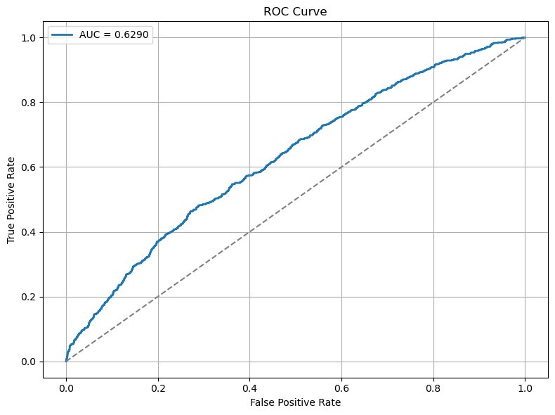

```python
# ROC Curve
fpr, tpr, roc_thresholds = roc_curve(y_test, y_pred_proba)
auc_score = roc_auc_score(y_test, y_pred_proba)

plt.figure(figsize=(8, 6))
plt.plot(fpr, tpr, label=f"AUC = {auc_score:.4f}", linewidth=2)
plt.plot([0, 1], [0, 1], linestyle="--", color="gray")
plt.xlabel("False Positive Rate")
plt.ylabel("True Positive Rate")
plt.title("ROC Curve")
plt.legend()
plt.grid(True)
plt.tight_layout()
plt.show()
```

# Gradient Boosting Classifier - Logistic Regression Alternative

###### Using HistGradientBoostingClassifier as it handles null values and has better AUC

###### Dataset Selection

```python
print('model_dataset shape:',model_dataset.shape)
# Define input features and target
X = model_dataset[['teetime_hour','last_score', 'teetime_hour_score',
       'last_sg_putt', 'last_sg_arg', 'last_sg_app', 'last_sg_ott',
       'last_sg_t2g', 'last_sg_total', 'last_driving_dist', 'last_driving_acc',
       'last_gir', 'last_scrambling', 'last_prox_rgh', 'last_prox_fw',
       'last_great_shots', 'last_poor_shots', 'score_lesr',
       'teetime_hour_lesr', 'sg_putt_lesr', 'sg_arg_lesr', 'sg_app_lesr',
       'sg_ott_lesr', 'sg_t2g_lesr', 'sg_total_lesr', 'driving_dist_lesr',
       'driving_acc_lesr', 'gir_lesr', 'scrambling_lesr', 'prox_rgh_lesr',
       'prox_fw_lesr', 'great_shots_lesr', 'poor_shots_lesr',
         'sg_putt_mean_3', 'sg_arg_mean_3', 'sg_app_mean_3', 'sg_ott_mean_3', 'sg_t2g_mean_3', 'sg_total_mean_3',
    'driving_dist_mean_3', 'driving_acc_mean_3', 'gir_mean_3', 'scrambling_mean_3', 'prox_rgh_mean_3', 'prox_fw_mean_3',
    'great_shots_mean_3', 'poor_shots_mean_3', 'round_score_mean_3',
    'sg_putt_avg_5', 'sg_arg_avg_5', 'sg_app_avg_5', 'sg_ott_avg_5', 'sg_t2g_avg_5', 'sg_total_avg_5',
    'driving_dist_avg_5', 'driving_acc_avg_5', 'gir_avg_5', 'scrambling_avg_5', 'prox_rgh_avg_5', 'prox_fw_avg_5',
    'great_shots_avg_5', 'poor_shots_avg_5', 'round_score_avg_5',

    'sg_putt_avg_last_1_tour', 'sg_arg_avg_last_1_tour', 'sg_app_avg_last_1_tour',
    'sg_ott_avg_last_1_tour', 'sg_t2g_avg_last_1_tour', 'sg_total_avg_last_1_tour',
    'driving_dist_avg_last_1_tour', 'driving_acc_avg_last_1_tour', 'gir_avg_last_1_tour',
    'scrambling_avg_last_1_tour', 'prox_rgh_avg_last_1_tour', 'prox_fw_avg_last_1_tour',
    'great_shots_avg_last_1_tour', 'poor_shots_avg_last_1_tour', 'round_score_avg_last_1_tour',

    'sg_putt_avg_last_3_tours', 'sg_arg_avg_last_3_tours', 'sg_app_avg_last_3_tours',
    'sg_ott_avg_last_3_tours', 'sg_t2g_avg_last_3_tours', 'sg_total_avg_last_3_tours',
    'driving_dist_avg_last_3_tours', 'driving_acc_avg_last_3_tours', 'gir_avg_last_3_tours',
    'scrambling_avg_last_3_tours', 'prox_rgh_avg_last_3_tours', 'prox_fw_avg_last_3_tours',
    'great_shots_avg_last_3_tours', 'poor_shots_avg_last_3_tours', 'round_score_avg_last_3_tours',

    'sg_putt_avg_last_5_tours', 'sg_arg_avg_last_5_tours', 'sg_app_avg_last_5_tours',
    'sg_ott_avg_last_5_tours', 'sg_t2g_avg_last_5_tours', 'sg_total_avg_last_5_tours',
    'driving_dist_avg_last_5_tours', 'driving_acc_avg_last_5_tours', 'gir_avg_last_5_tours',
    'scrambling_avg_last_5_tours', 'prox_rgh_avg_last_5_tours', 'prox_fw_avg_last_5_tours',
    'great_shots_avg_last_5_tours', 'poor_shots_avg_last_5_tours', 'round_score_avg_last_5_tours',

    'sg_putt_avg_last_10_tours','sg_arg_avg_last_10_tours','sg_app_avg_last_10_tours','sg_ott_avg_last_10_tours',
    'sg_t2g_avg_last_10_tours','sg_total_avg_last_10_tours','driving_dist_avg_last_10_tours','driving_acc_avg_last_10_tours',
    'gir_avg_last_10_tours','scrambling_avg_last_10_tours','prox_rgh_avg_last_10_tours','prox_fw_avg_last_10_tours',
    'great_shots_avg_last_10_tours','poor_shots_avg_last_10_tours','round_score_avg_last_10_tours',

    'ytd_tournament_counts','Humidity (%)','cleaned_temperature','cleaned_wind_speed',
    'sunny','raining','foggy','humid','breezy','dry','warm','hot','cool','mild','coastal','tropical',

    # Weighted proximity + sg_putt interactions
    'weighted_proximity_last', 'weighted_proximity_x_sg_putt_last',
    'weighted_proximity_lesr', 'weighted_proximity_x_sg_putt_lesr',
    'weighted_proximity_mean_3', 'weighted_proximity_x_sg_putt_mean_3',
    'weighted_proximity_avg_5', 'weighted_proximity_x_sg_putt_avg_5',
    'weighted_proximity_avg_last_1_tour', 'weighted_proximity_x_sg_putt_avg_last_1_tour',
    'weighted_proximity_avg_last_3_tours', 'weighted_proximity_x_sg_putt_avg_last_3_tours',
    'weighted_proximity_avg_last_5_tours', 'weighted_proximity_x_sg_putt_avg_last_5_tours',
    'weighted_proximity_avg_last_10_tours', 'weighted_proximity_x_sg_putt_avg_last_10_tours',

    # Wind × Driving Distance
    'wind_x_driving_dist_last', 'wind_x_driving_dist_lesr', 'wind_x_driving_dist_mean_3',
    'wind_x_driving_dist_avg_5', 'wind_x_driving_dist_avg_last_1_tour',
    'wind_x_driving_dist_avg_last_3_tours', 'wind_x_driving_dist_avg_last_5_tours',
    'wind_x_driving_dist_avg_last_10_tours',

    # Humidity × Weighted Proximity
    'humidity_x_weighted_prox_last', 'humidity_x_weighted_prox_lesr', 'humidity_x_weighted_prox_mean_3',
    'humidity_x_weighted_prox_avg_5', 'humidity_x_weighted_prox_avg_last_1_tour',
    'humidity_x_weighted_prox_avg_last_3_tours', 'humidity_x_weighted_prox_avg_last_5_tours',
    'humidity_x_weighted_prox_avg_last_10_tours',

    # Temperature × SG Putt
    'temp_x_sg_putt_last', 'temp_x_sg_putt_lesr', 'temp_x_sg_putt_mean_3',
    'temp_x_sg_putt_avg_5', 'temp_x_sg_putt_avg_last_1_tour',
    'temp_x_sg_putt_avg_last_3_tours', 'temp_x_sg_putt_avg_last_5_tours',
    'temp_x_sg_putt_avg_last_10_tours',

    # round_score averages
    'last_1_year_round_score_course_avg',
    'last_3_year_round_score_course_avg',
    'last_5_year_round_score_course_avg',

    # sg_putt averages
    'last_1_year_sg_putt_course_avg',
    'last_3_year_sg_putt_course_avg',
    'last_5_year_sg_putt_course_avg',

    # sg_arg averages
    'last_1_year_sg_arg_course_avg',
    'last_3_year_sg_arg_course_avg',
    'last_5_year_sg_arg_course_avg',

    # sg_app averages
    'last_1_year_sg_app_course_avg',
    'last_3_year_sg_app_course_avg',
    'last_5_year_sg_app_course_avg',

    # sg_ott averages
    'last_1_year_sg_ott_course_avg',
    'last_3_year_sg_ott_course_avg',
    'last_5_year_sg_ott_course_avg',

    # sg_t2g averages
    'last_1_year_sg_t2g_course_avg',
    'last_3_year_sg_t2g_course_avg',
    'last_5_year_sg_t2g_course_avg',

    # sg_total averages
    'last_1_year_sg_total_course_avg',
    'last_3_year_sg_total_course_avg',
    'last_5_year_sg_total_course_avg',

    # driving_dist averages
    'last_1_year_driving_dist_course_avg',
    'last_3_year_driving_dist_course_avg',
    'last_5_year_driving_dist_course_avg',

    # driving_acc averages
    'last_1_year_driving_acc_course_avg',
    'last_3_year_driving_acc_course_avg',
    'last_5_year_driving_acc_course_avg',

    # gir averages
    'last_1_year_gir_course_avg',
    'last_3_year_gir_course_avg',
    'last_5_year_gir_course_avg',

    # scrambling averages
    'last_1_year_scrambling_course_avg',
    'last_3_year_scrambling_course_avg',
    'last_5_year_scrambling_course_avg',

    # prox_rgh averages
    'last_1_year_prox_rgh_course_avg',
    'last_3_year_prox_rgh_course_avg',
    'last_5_year_prox_rgh_course_avg',

    # prox_fw averages
    'last_1_year_prox_fw_course_avg',
    'last_3_year_prox_fw_course_avg',
    'last_5_year_prox_fw_course_avg',

    # great_shots averages
    'last_1_year_great_shots_course_avg',
    'last_3_year_great_shots_course_avg',
    'last_5_year_great_shots_course_avg',

    # poor_shots averages
    'last_1_year_poor_shots_course_avg',
    'last_3_year_poor_shots_course_avg',
    'last_5_year_poor_shots_course_avg',

    'made_cut_last10', 'made_cut_last20', 'made_cut_last50', 'made_cut_ytd',

    'course_rating', 'slope','acres_of_fairway', 'acres_of_rough',

    'is_bentgrass_greens', 'is_bermuda_greens', 'is_poa_annua_greens', 'is_fescue_greens', 'is_paspalum_greens',
    'is_kikuyu_greens', 'is_zoysiagrass_fairway', 'is_fescue_fairway', 'is_bentgrass_fairway', 'is_bermuda_fairway',
 'is_ryegrass_fairway', 'is_kikuyu_fairway', 'is_poa_annua_fairway', 'is_bluegrass_fairway', 'is_paspalum_fairway',

    'round_1']]
y = model_dataset['is_top_20_round']
print('X Shape:',X.shape)
classification_columns=X.columns
```

```
model_dataset shape: (44931, 260)
X Shape: (44931, 248)
```

###### Splitting the Dataset

```python
# Split
X_train, X_test, y_train, y_test = train_test_split(X, y, test_size=0.2, random_state=42)
```

###### Training the model

```python
# Train model
model_classifier = HistGradientBoostingClassifier(l2_regularization=50.0,
                                      max_iter=500,
                                      max_leaf_nodes=63,
                                      min_samples_leaf=50,
                                      learning_rate=0.01)
model_classifier.fit(X_train, y_train)
```

```
HistGradientBoostingClassifier(l2_regularization=50.0, learning_rate=0.01,
                               max_iter=500, max_leaf_nodes=63,
                               min_samples_leaf=50)
```

```python
# Evaluate
y_pred = model_classifier.predict(X_test)
y_prob = model_classifier.predict_proba(X_test)[:, 1]
```

###### Validation

```python
# y_true = true labels
# y_pred = model predictions (0 or 1)
# y_prob = model predicted probabilities for class 1 (optional)

# Example:
print("Accuracy:", accuracy_score(y_test, y_pred))
print("Precision:", precision_score(y_test, y_pred))
print("Recall:", recall_score(y_test, y_pred))
print("F1 Score:", f1_score(y_test, y_pred))

# If you have prediction probabilities:
print("ROC AUC:", roc_auc_score(y_test, y_prob))
```

```
Accuracy: 0.8047179258929565
Precision: 0.7352941176470589
Recall: 0.04159733777038269
F1 Score: 0.07874015748031496
ROC AUC: 0.6678388886006618
```

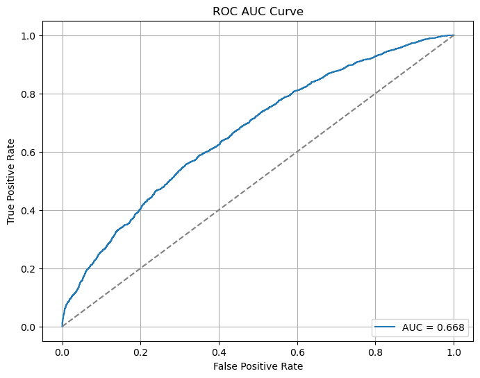

```python
# Assume you have:
# y_true = true labels (0/1)
# y_prob = predicted probabilities for class 1

# Step 1: Calculate ROC curve points
fpr, tpr, thresholds = roc_curve(y_test, y_prob)

# Step 2: Calculate AUC score
auc_score = roc_auc_score(y_test, y_prob)

# Step 3: Plot ROC curve
plt.figure(figsize=(8, 6))
plt.plot(fpr, tpr, label=f'AUC = {auc_score:.3f}')
plt.plot([0, 1], [0, 1], linestyle='--', color='gray')  # random guess line
plt.xlabel('False Positive Rate')
plt.ylabel('True Positive Rate')
plt.title('ROC AUC Curve')
plt.legend(loc='lower right')
plt.grid()
plt.show()
```

# Predictions

```python
# Load tee times
final_dgid_data_cj_cup=pd.read_csv('final_dgid_data_cj_cup.csv')
final_dgid_data_cj_cup.head()
```

|  | Player Name | Tee Time | dg_id | ytd_tournament_counts |
| --- | --- | --- | --- | --- |
| 0 | Charley Hoffman | 7:50 a.m. | 5768.0 | 3.0 |
| 1 | Matt Kuchar | 8:34 a.m. | 6169.0 | 3.0 |
| 2 | Aaron Baddeley | 1:22 p.m. | 6252.0 | 3.0 |
| 3 | Zach Johnson | 1:44 p.m. | 6986.0 | 6.0 |
| 4 | Scott Gutschewski | 8:01 a.m. | 7305.0 | 1.0 |

```python
players_in_cj_cup=final_dgid_data_cj_cup.merge(dataset.groupby('dg_id')['player_name'].min().reset_index(),how='inner',on='dg_id').sort_values(by='dg_id')
players_in_cj_cup['dg_id']=players_in_cj_cup['dg_id'].astype(int)
```

```python
from datetime import datetime

def parse_teetime(teetime_str):
    if pd.isnull(teetime_str):
        return None
    # Normalize to match expected format (e.g., "7:50 a.m." -> "7:50 AM")
    cleaned = teetime_str.strip().replace('.', '').upper()
    return datetime.strptime(cleaned, "%I:%M %p").hour

players_in_cj_cup['teetime_hour'] = players_in_cj_cup['Tee Time'].apply(parse_teetime)

# Optional: Preview
players_in_cj_cup.head()
```

|  | Player Name | Tee Time | dg_id | ytd_tournament_counts | player_name | teetime_hour |
| --- | --- | --- | --- | --- | --- | --- |
| 0 | Charley Hoffman | 7:50 a.m. | 5768 | 3.0 | Hoffman, Charley | 7 |
| 1 | Matt Kuchar | 8:34 a.m. | 6169 | 3.0 | Kuchar, Matt | 8 |
| 2 | Aaron Baddeley | 1:22 p.m. | 6252 | 3.0 | Baddeley, Aaron | 13 |
| 3 | Zach Johnson | 1:44 p.m. | 6986 | 6.0 | Johnson, Zach | 13 |
| 4 | Scott Gutschewski | 8:01 a.m. | 7305 | 1.0 | Gutschewski, Scott | 8 |

## Round 1 Regression Predictions

###### Preparing Dataset For Round 1 Predictions

```
* Using Last known performance data and current weather and course context to predict.
* Handling Missing Values
    * Gettting the last know value for the metric.
    * Use median if last value does not exist.
```

```python
# Your clean SQL query in triple quotes
query = """

select
    *
from
(
    SELECT
        row_id,
        tournament_order,
        year,
        event_id,
        dg_id,
        round_num,
        COALESCE(last_sg_putt, LAST_VALUE(last_sg_putt IGNORE NULLS) OVER (PARTITION BY dg_id ORDER BY row_id ROWS BETWEEN UNBOUNDED PRECEDING AND CURRENT ROW)) AS last_sg_putt,
        COALESCE(last_sg_app, LAST_VALUE(last_sg_app IGNORE NULLS) OVER (PARTITION BY dg_id ORDER BY row_id ROWS BETWEEN UNBOUNDED PRECEDING AND CURRENT ROW)) AS last_sg_app,
        COALESCE(last_sg_total, LAST_VALUE(last_sg_total IGNORE NULLS) OVER (PARTITION BY dg_id ORDER BY row_id ROWS BETWEEN UNBOUNDED PRECEDING AND CURRENT ROW)) AS last_sg_total,
        COALESCE(score_lesr, LAST_VALUE(score_lesr IGNORE NULLS) OVER (PARTITION BY dg_id ORDER BY row_id ROWS BETWEEN UNBOUNDED PRECEDING AND CURRENT ROW)) AS score_lesr,
        COALESCE(sg_putt_lesr, LAST_VALUE(sg_putt_lesr IGNORE NULLS) OVER (PARTITION BY dg_id ORDER BY row_id ROWS BETWEEN UNBOUNDED PRECEDING AND CURRENT ROW)) AS sg_putt_lesr,
        COALESCE(driving_dist_lesr, LAST_VALUE(driving_dist_lesr IGNORE NULLS) OVER (PARTITION BY dg_id ORDER BY row_id ROWS BETWEEN UNBOUNDED PRECEDING AND CURRENT ROW)) AS driving_dist_lesr,
        COALESCE(sg_total_mean_3, LAST_VALUE(sg_total_mean_3 IGNORE NULLS) OVER (PARTITION BY dg_id ORDER BY row_id ROWS BETWEEN UNBOUNDED PRECEDING AND CURRENT ROW)) AS sg_total_mean_3,
        COALESCE(sg_arg_avg_5, LAST_VALUE(sg_arg_avg_5 IGNORE NULLS) OVER (PARTITION BY dg_id ORDER BY row_id ROWS BETWEEN UNBOUNDED PRECEDING AND CURRENT ROW)) AS sg_arg_avg_5,
        COALESCE(sg_arg_avg_last_1_tour, LAST_VALUE(sg_arg_avg_last_1_tour IGNORE NULLS) OVER (PARTITION BY dg_id ORDER BY row_id ROWS BETWEEN UNBOUNDED PRECEDING AND CURRENT ROW)) AS sg_arg_avg_last_1_tour,
        COALESCE(sg_app_avg_last_1_tour, LAST_VALUE(sg_app_avg_last_1_tour IGNORE NULLS) OVER (PARTITION BY dg_id ORDER BY row_id ROWS BETWEEN UNBOUNDED PRECEDING AND CURRENT ROW)) AS sg_app_avg_last_1_tour,
        COALESCE(sg_ott_avg_last_1_tour, LAST_VALUE(sg_ott_avg_last_1_tour IGNORE NULLS) OVER (PARTITION BY dg_id ORDER BY row_id ROWS BETWEEN UNBOUNDED PRECEDING AND CURRENT ROW)) AS sg_ott_avg_last_1_tour,
        COALESCE(sg_t2g_avg_last_1_tour, LAST_VALUE(sg_t2g_avg_last_1_tour IGNORE NULLS) OVER (PARTITION BY dg_id ORDER BY row_id ROWS BETWEEN UNBOUNDED PRECEDING AND CURRENT ROW)) AS sg_t2g_avg_last_1_tour,
        COALESCE(gir_avg_last_1_tour, LAST_VALUE(gir_avg_last_1_tour IGNORE NULLS) OVER (PARTITION BY dg_id ORDER BY row_id ROWS BETWEEN UNBOUNDED PRECEDING AND CURRENT ROW)) AS gir_avg_last_1_tour,
        COALESCE(prox_fw_avg_last_1_tour, LAST_VALUE(prox_fw_avg_last_1_tour IGNORE NULLS) OVER (PARTITION BY dg_id ORDER BY row_id ROWS BETWEEN UNBOUNDED PRECEDING AND CURRENT ROW)) AS prox_fw_avg_last_1_tour,
        COALESCE(round_score_avg_last_1_tour, LAST_VALUE(round_score_avg_last_1_tour IGNORE NULLS) OVER (PARTITION BY dg_id ORDER BY row_id ROWS BETWEEN UNBOUNDED PRECEDING AND CURRENT ROW)) AS round_score_avg_last_1_tour,
        COALESCE(sg_total_avg_last_3_tours, LAST_VALUE(sg_total_avg_last_3_tours IGNORE NULLS) OVER (PARTITION BY dg_id ORDER BY row_id ROWS BETWEEN UNBOUNDED PRECEDING AND CURRENT ROW)) AS sg_total_avg_last_3_tours,
        COALESCE(gir_avg_last_5_tours, LAST_VALUE(gir_avg_last_5_tours IGNORE NULLS) OVER (PARTITION BY dg_id ORDER BY row_id ROWS BETWEEN UNBOUNDED PRECEDING AND CURRENT ROW)) AS gir_avg_last_5_tours,
        COALESCE(round_score_avg_last_5_tours, LAST_VALUE(round_score_avg_last_5_tours IGNORE NULLS) OVER (PARTITION BY dg_id ORDER BY row_id ROWS BETWEEN UNBOUNDED PRECEDING AND CURRENT ROW)) AS round_score_avg_last_5_tours,
        COALESCE(sg_putt_avg_last_10_tours, LAST_VALUE(sg_putt_avg_last_10_tours IGNORE NULLS) OVER (PARTITION BY dg_id ORDER BY row_id ROWS BETWEEN UNBOUNDED PRECEDING AND CURRENT ROW)) AS sg_putt_avg_last_10_tours,
        COALESCE(sg_arg_avg_last_10_tours, LAST_VALUE(sg_arg_avg_last_10_tours IGNORE NULLS) OVER (PARTITION BY dg_id ORDER BY row_id ROWS BETWEEN UNBOUNDED PRECEDING AND CURRENT ROW)) AS sg_arg_avg_last_10_tours,
        COALESCE(sg_app_avg_last_10_tours, LAST_VALUE(sg_app_avg_last_10_tours IGNORE NULLS) OVER (PARTITION BY dg_id ORDER BY row_id ROWS BETWEEN UNBOUNDED PRECEDING AND CURRENT ROW)) AS sg_app_avg_last_10_tours,
        COALESCE(sg_ott_avg_last_10_tours, LAST_VALUE(sg_ott_avg_last_10_tours IGNORE NULLS) OVER (PARTITION BY dg_id ORDER BY row_id ROWS BETWEEN UNBOUNDED PRECEDING AND CURRENT ROW)) AS sg_ott_avg_last_10_tours,
        COALESCE(great_shots_avg_last_10_tours, LAST_VALUE(great_shots_avg_last_10_tours IGNORE NULLS) OVER (PARTITION BY dg_id ORDER BY row_id ROWS BETWEEN UNBOUNDED PRECEDING AND CURRENT ROW)) AS great_shots_avg_last_10_tours,
        -- ... continued below ...
        COALESCE(weighted_proximity_mean_3, LAST_VALUE(weighted_proximity_mean_3 IGNORE NULLS) OVER (PARTITION BY dg_id ORDER BY row_id ROWS BETWEEN UNBOUNDED PRECEDING AND CURRENT ROW)) AS weighted_proximity_mean_3,
        COALESCE(wind_x_driving_dist_lesr, LAST_VALUE(wind_x_driving_dist_lesr IGNORE NULLS) OVER (PARTITION BY dg_id ORDER BY row_id ROWS BETWEEN UNBOUNDED PRECEDING AND CURRENT ROW)) AS wind_x_driving_dist_lesr,
        COALESCE(wind_x_driving_dist_avg_5, LAST_VALUE(wind_x_driving_dist_avg_5 IGNORE NULLS) OVER (PARTITION BY dg_id ORDER BY row_id ROWS BETWEEN UNBOUNDED PRECEDING AND CURRENT ROW)) AS wind_x_driving_dist_avg_5,
        COALESCE(humidity_x_weighted_prox_mean_3, LAST_VALUE(humidity_x_weighted_prox_mean_3 IGNORE NULLS) OVER (PARTITION BY dg_id ORDER BY row_id ROWS BETWEEN UNBOUNDED PRECEDING AND CURRENT ROW)) AS humidity_x_weighted_prox_mean_3,
        COALESCE(last_3_year_round_score_course_avg, LAST_VALUE(last_3_year_round_score_course_avg IGNORE NULLS) OVER (PARTITION BY dg_id ORDER BY row_id ROWS BETWEEN UNBOUNDED PRECEDING AND CURRENT ROW)) AS last_3_year_round_score_course_avg,
        COALESCE(last_1_year_sg_putt_course_avg, LAST_VALUE(last_1_year_sg_putt_course_avg IGNORE NULLS) OVER (PARTITION BY dg_id ORDER BY row_id ROWS BETWEEN UNBOUNDED PRECEDING AND CURRENT ROW)) AS last_1_year_sg_putt_course_avg,
        COALESCE(last_5_year_sg_putt_course_avg, LAST_VALUE(last_5_year_sg_putt_course_avg IGNORE NULLS) OVER (PARTITION BY dg_id ORDER BY row_id ROWS BETWEEN UNBOUNDED PRECEDING AND CURRENT ROW)) AS last_5_year_sg_putt_course_avg,
        COALESCE(last_1_year_sg_arg_course_avg, LAST_VALUE(last_1_year_sg_arg_course_avg IGNORE NULLS) OVER (PARTITION BY dg_id ORDER BY row_id ROWS BETWEEN UNBOUNDED PRECEDING AND CURRENT ROW)) AS last_1_year_sg_arg_course_avg,
        COALESCE(last_3_year_sg_arg_course_avg, LAST_VALUE(last_3_year_sg_arg_course_avg IGNORE NULLS) OVER (PARTITION BY dg_id ORDER BY row_id ROWS BETWEEN UNBOUNDED PRECEDING AND CURRENT ROW)) AS last_3_year_sg_arg_course_avg,
        COALESCE(last_5_year_sg_arg_course_avg, LAST_VALUE(last_5_year_sg_arg_course_avg IGNORE NULLS) OVER (PARTITION BY dg_id ORDER BY row_id ROWS BETWEEN UNBOUNDED PRECEDING AND CURRENT ROW)) AS last_5_year_sg_arg_course_avg,
        COALESCE(last_3_year_sg_app_course_avg, LAST_VALUE(last_3_year_sg_app_course_avg IGNORE NULLS) OVER (PARTITION BY dg_id ORDER BY row_id ROWS BETWEEN UNBOUNDED PRECEDING AND CURRENT ROW)) AS last_3_year_sg_app_course_avg,
        COALESCE(last_1_year_sg_ott_course_avg, LAST_VALUE(last_1_year_sg_ott_course_avg IGNORE NULLS) OVER (PARTITION BY dg_id ORDER BY row_id ROWS BETWEEN UNBOUNDED PRECEDING AND CURRENT ROW)) AS last_1_year_sg_ott_course_avg,
        COALESCE(last_5_year_sg_ott_course_avg, LAST_VALUE(last_5_year_sg_ott_course_avg IGNORE NULLS) OVER (PARTITION BY dg_id ORDER BY row_id ROWS BETWEEN UNBOUNDED PRECEDING AND CURRENT ROW)) AS last_5_year_sg_ott_course_avg,
        COALESCE(last_1_year_sg_t2g_course_avg, LAST_VALUE(last_1_year_sg_t2g_course_avg IGNORE NULLS) OVER (PARTITION BY dg_id ORDER BY row_id ROWS BETWEEN UNBOUNDED PRECEDING AND CURRENT ROW)) AS last_1_year_sg_t2g_course_avg,
        COALESCE(last_5_year_sg_t2g_course_avg, LAST_VALUE(last_5_year_sg_t2g_course_avg IGNORE NULLS) OVER (PARTITION BY dg_id ORDER BY row_id ROWS BETWEEN UNBOUNDED PRECEDING AND CURRENT ROW)) AS last_5_year_sg_t2g_course_avg,
        COALESCE(last_3_year_sg_total_course_avg, LAST_VALUE(last_3_year_sg_total_course_avg IGNORE NULLS) OVER (PARTITION BY dg_id ORDER BY row_id ROWS BETWEEN UNBOUNDED PRECEDING AND CURRENT ROW)) AS last_3_year_sg_total_course_avg,
        COALESCE(last_5_year_sg_total_course_avg, LAST_VALUE(last_5_year_sg_total_course_avg IGNORE NULLS) OVER (PARTITION BY dg_id ORDER BY row_id ROWS BETWEEN UNBOUNDED PRECEDING AND CURRENT ROW)) AS last_5_year_sg_total_course_avg,
        COALESCE(last_1_year_driving_dist_course_avg, LAST_VALUE(last_1_year_driving_dist_course_avg IGNORE NULLS) OVER (PARTITION BY dg_id ORDER BY row_id ROWS BETWEEN UNBOUNDED PRECEDING AND CURRENT ROW)) AS last_1_year_driving_dist_course_avg,
        COALESCE(last_3_year_driving_dist_course_avg, LAST_VALUE(last_3_year_driving_dist_course_avg IGNORE NULLS) OVER (PARTITION BY dg_id ORDER BY row_id ROWS BETWEEN UNBOUNDED PRECEDING AND CURRENT ROW)) AS last_3_year_driving_dist_course_avg,
        COALESCE(last_5_year_driving_dist_course_avg, LAST_VALUE(last_5_year_driving_dist_course_avg IGNORE NULLS) OVER (PARTITION BY dg_id ORDER BY row_id ROWS BETWEEN UNBOUNDED PRECEDING AND CURRENT ROW)) AS last_5_year_driving_dist_course_avg,
        COALESCE(last_1_year_driving_acc_course_avg, LAST_VALUE(last_1_year_driving_acc_course_avg IGNORE NULLS) OVER (PARTITION BY dg_id ORDER BY row_id ROWS BETWEEN UNBOUNDED PRECEDING AND CURRENT ROW)) AS last_1_year_driving_acc_course_avg,
        COALESCE(last_3_year_driving_acc_course_avg, LAST_VALUE(last_3_year_driving_acc_course_avg IGNORE NULLS) OVER (PARTITION BY dg_id ORDER BY row_id ROWS BETWEEN UNBOUNDED PRECEDING AND CURRENT ROW)) AS last_3_year_driving_acc_course_avg,
        COALESCE(last_3_year_gir_course_avg, LAST_VALUE(last_3_year_gir_course_avg IGNORE NULLS) OVER (PARTITION BY dg_id ORDER BY row_id ROWS BETWEEN UNBOUNDED PRECEDING AND CURRENT ROW)) AS last_3_year_gir_course_avg,
        COALESCE(last_5_year_gir_course_avg, LAST_VALUE(last_5_year_gir_course_avg IGNORE NULLS) OVER (PARTITION BY dg_id ORDER BY row_id ROWS BETWEEN UNBOUNDED PRECEDING AND CURRENT ROW)) AS last_5_year_gir_course_avg,
        COALESCE(last_1_year_scrambling_course_avg, LAST_VALUE(last_1_year_scrambling_course_avg IGNORE NULLS) OVER (PARTITION BY dg_id ORDER BY row_id ROWS BETWEEN UNBOUNDED PRECEDING AND CURRENT ROW)) AS last_1_year_scrambling_course_avg,
        COALESCE(last_3_year_scrambling_course_avg, LAST_VALUE(last_3_year_scrambling_course_avg IGNORE NULLS) OVER (PARTITION BY dg_id ORDER BY row_id ROWS BETWEEN UNBOUNDED PRECEDING AND CURRENT ROW)) AS last_3_year_scrambling_course_avg,
        COALESCE(last_1_year_prox_rgh_course_avg, LAST_VALUE(last_1_year_prox_rgh_course_avg IGNORE NULLS) OVER (PARTITION BY dg_id ORDER BY row_id ROWS BETWEEN UNBOUNDED PRECEDING AND CURRENT ROW)) AS last_1_year_prox_rgh_course_avg,
        COALESCE(last_3_year_prox_rgh_course_avg, LAST_VALUE(last_3_year_prox_rgh_course_avg IGNORE NULLS) OVER (PARTITION BY dg_id ORDER BY row_id ROWS BETWEEN UNBOUNDED PRECEDING AND CURRENT ROW)) AS last_3_year_prox_rgh_course_avg,
        COALESCE(last_5_year_prox_rgh_course_avg, LAST_VALUE(last_5_year_prox_rgh_course_avg IGNORE NULLS) OVER (PARTITION BY dg_id ORDER BY row_id ROWS BETWEEN UNBOUNDED PRECEDING AND CURRENT ROW)) AS last_5_year_prox_rgh_course_avg,
        COALESCE(last_1_year_prox_fw_course_avg, LAST_VALUE(last_1_year_prox_fw_course_avg IGNORE NULLS) OVER (PARTITION BY dg_id ORDER BY row_id ROWS BETWEEN UNBOUNDED PRECEDING AND CURRENT ROW)) AS last_1_year_prox_fw_course_avg,
        COALESCE(last_3_year_prox_fw_course_avg, LAST_VALUE(last_3_year_prox_fw_course_avg IGNORE NULLS) OVER (PARTITION BY dg_id ORDER BY row_id ROWS BETWEEN UNBOUNDED PRECEDING AND CURRENT ROW)) AS last_3_year_prox_fw_course_avg,
```

```python
        COALESCE(last_5_year_prox_fw_course_avg, LAST_VALUE(last_5_year_prox_fw_course_avg IGNORE NULLS) OVER (PARTITION BY dg_id ORDER BY row_id ROWS BETWEEN UNBOUNDED PRECEDING AND CURRENT ROW)) AS last_5_year_prox_fw_course_avg,
        COALESCE(last_1_year_great_shots_course_avg, LAST_VALUE(last_1_year_great_shots_course_avg IGNORE NULLS) OVER (PARTITION BY dg_id ORDER BY row_id ROWS BETWEEN UNBOUNDED PRECEDING AND CURRENT ROW)) AS last_1_year_great_shots_course_avg,
        COALESCE(last_3_year_great_shots_course_avg, LAST_VALUE(last_3_year_great_shots_course_avg IGNORE NULLS) OVER (PARTITION BY dg_id ORDER BY row_id ROWS BETWEEN UNBOUNDED PRECEDING AND CURRENT ROW)) AS last_3_year_great_shots_course_avg,
        COALESCE(last_1_year_poor_shots_course_avg, LAST_VALUE(last_1_year_poor_shots_course_avg IGNORE NULLS) OVER (PARTITION BY dg_id ORDER BY row_id ROWS BETWEEN UNBOUNDED PRECEDING AND CURRENT ROW)) AS last_1_year_poor_shots_course_avg,
        COALESCE(made_cut_last10, LAST_VALUE(made_cut_last10 IGNORE NULLS) OVER (PARTITION BY dg_id ORDER BY row_id ROWS BETWEEN UNBOUNDED PRECEDING AND CURRENT ROW)) AS made_cut_last10,
        COALESCE(made_cut_last20, LAST_VALUE(made_cut_last20 IGNORE NULLS) OVER (PARTITION BY dg_id ORDER BY row_id ROWS BETWEEN UNBOUNDED PRECEDING AND CURRENT ROW)) AS made_cut_last20,
        COALESCE(made_cut_last50, LAST_VALUE(made_cut_last50 IGNORE NULLS) OVER (PARTITION BY dg_id ORDER BY row_id ROWS BETWEEN UNBOUNDED PRECEDING AND CURRENT ROW)) AS made_cut_last50,

        row_number () over (partition by dg_id order by row_id desc) as rn
    FROM
        dataset
    where
        dg_id in (select cast(dg_id as int) as dg_id from players_in_cj_cup where dg_id is not null)
        and round_num in (1)
    order by
        dg_id,row_id desc
)b
where
    rn=1
"""

# Run the query using DuckDB
round_one = duckdb.query(query).to_df()

# Display the result
print("round_one shape",round_one.shape)
```

```
round_one shape (147, 68)
```

```python
weather_course_context=dataset[
    (dataset['course_name']=='TPC Craig Ranch')
    &
    (dataset['year']==2023)][['course_rating', 'slope', 'acres_of_fairway', 'acres_of_rough', 'is_bentgrass_greens',
 'is_bermuda_greens', 'is_zoysiagrass_fairway', 'is_bentgrass_fairway', 'is_bermuda_fairway', 'is_ryegrass_fairway',
 'is_kikuyu_fairway', 'is_bluegrass_fairway']].drop_duplicates()
```

```python
weather_course_context['Humidity (%)']=0.625
weather_course_context['cleaned_temperature']=79
weather_course_context['sunny']=0
weather_course_context['foggy']=0
weather_course_context['breezy']=1
weather_course_context['dry']=0
weather_course_context['warm']=0
weather_course_context['hot']=0
weather_course_context['cool']=1
weather_course_context['mild']=0
weather_course_context['coastal']=0
```

```python
round_one['key']=1
weather_course_context['key']=1
```

```python
# Perform cross join
round_one = round_one.merge(weather_course_context, how='inner',on='key')
```

```python
round_one=players_in_cj_cup.merge(round_one,on='dg_id')
```

```python
missing = [col for col in final_features if col not in round_one.columns]
print("Missing columns:", missing)
```

```
Missing columns: []
```

###### Score Predictions

```python
round_one_X=round_one[final_features]
```

```python
# Impute all columns with their median
round_one_X_imputed = round_one_X.apply(lambda col: col.fillna(col.median()) if col.dtype in ['float64', 'int64'] else col)
```

```python
r1_predictions = lr_model.predict(round_one_X_imputed)
# Add predictions to the original dataframe
round_one['predicted_value'] = r1_predictions
```

## Round 2 Regression Predictions

###### Preparing Dataset For Round 2 Predictions

```
* Using Last known performance data and current weather and course context to predict.
* Handling Missing Values
    * Gettting the last know value for the metric
    * Use median if last value does not exist.
```

```python
# Your clean SQL query in triple quotes
query = """

select
    *
from
(
    SELECT
        row_id,
        tournament_order,
        year,
        event_id,
        dg_id,
        round_num,
        COALESCE(last_sg_putt, LAST_VALUE(last_sg_putt IGNORE NULLS) OVER (PARTITION BY dg_id ORDER BY row_id ROWS BETWEEN UNBOUNDED PRECEDING AND CURRENT ROW)) AS last_sg_putt,
        COALESCE(last_sg_app, LAST_VALUE(last_sg_app IGNORE NULLS) OVER (PARTITION BY dg_id ORDER BY row_id ROWS BETWEEN UNBOUNDED PRECEDING AND CURRENT ROW)) AS last_sg_app,
        COALESCE(last_sg_total, LAST_VALUE(last_sg_total IGNORE NULLS) OVER (PARTITION BY dg_id ORDER BY row_id ROWS BETWEEN UNBOUNDED PRECEDING AND CURRENT ROW)) AS last_sg_total,
        COALESCE(score_lesr, LAST_VALUE(score_lesr IGNORE NULLS) OVER (PARTITION BY dg_id ORDER BY row_id ROWS BETWEEN UNBOUNDED PRECEDING AND CURRENT ROW)) AS score_lesr,
        COALESCE(sg_putt_lesr, LAST_VALUE(sg_putt_lesr IGNORE NULLS) OVER (PARTITION BY dg_id ORDER BY row_id ROWS BETWEEN UNBOUNDED PRECEDING AND CURRENT ROW)) AS sg_putt_lesr,
        COALESCE(driving_dist_lesr, LAST_VALUE(driving_dist_lesr IGNORE NULLS) OVER (PARTITION BY dg_id ORDER BY row_id ROWS BETWEEN UNBOUNDED PRECEDING AND CURRENT ROW)) AS driving_dist_lesr,
        COALESCE(sg_total_mean_3, LAST_VALUE(sg_total_mean_3 IGNORE NULLS) OVER (PARTITION BY dg_id ORDER BY row_id ROWS BETWEEN UNBOUNDED PRECEDING AND CURRENT ROW)) AS sg_total_mean_3,
        COALESCE(sg_arg_avg_5, LAST_VALUE(sg_arg_avg_5 IGNORE NULLS) OVER (PARTITION BY dg_id ORDER BY row_id ROWS BETWEEN UNBOUNDED PRECEDING AND CURRENT ROW)) AS sg_arg_avg_5,
        COALESCE(sg_arg_avg_last_1_tour, LAST_VALUE(sg_arg_avg_last_1_tour IGNORE NULLS) OVER (PARTITION BY dg_id ORDER BY row_id ROWS BETWEEN UNBOUNDED PRECEDING AND CURRENT ROW)) AS sg_arg_avg_last_1_tour,
        COALESCE(sg_app_avg_last_1_tour, LAST_VALUE(sg_app_avg_last_1_tour IGNORE NULLS) OVER (PARTITION BY dg_id ORDER BY row_id ROWS BETWEEN UNBOUNDED PRECEDING AND CURRENT ROW)) AS sg_app_avg_last_1_tour,
        COALESCE(sg_ott_avg_last_1_tour, LAST_VALUE(sg_ott_avg_last_1_tour IGNORE NULLS) OVER (PARTITION BY dg_id ORDER BY row_id ROWS BETWEEN UNBOUNDED PRECEDING AND CURRENT ROW)) AS sg_ott_avg_last_1_tour,
        COALESCE(sg_t2g_avg_last_1_tour, LAST_VALUE(sg_t2g_avg_last_1_tour IGNORE NULLS) OVER (PARTITION BY dg_id ORDER BY row_id ROWS BETWEEN UNBOUNDED PRECEDING AND CURRENT ROW)) AS sg_t2g_avg_last_1_tour,
        COALESCE(gir_avg_last_1_tour, LAST_VALUE(gir_avg_last_1_tour IGNORE NULLS) OVER (PARTITION BY dg_id ORDER BY row_id ROWS BETWEEN UNBOUNDED PRECEDING AND CURRENT ROW)) AS gir_avg_last_1_tour,
        COALESCE(prox_fw_avg_last_1_tour, LAST_VALUE(prox_fw_avg_last_1_tour IGNORE NULLS) OVER (PARTITION BY dg_id ORDER BY row_id ROWS BETWEEN UNBOUNDED PRECEDING AND CURRENT ROW)) AS prox_fw_avg_last_1_tour,
        COALESCE(round_score_avg_last_1_tour, LAST_VALUE(round_score_avg_last_1_tour IGNORE NULLS) OVER (PARTITION BY dg_id ORDER BY row_id ROWS BETWEEN UNBOUNDED PRECEDING AND CURRENT ROW)) AS round_score_avg_last_1_tour,
        COALESCE(sg_total_avg_last_3_tours, LAST_VALUE(sg_total_avg_last_3_tours IGNORE NULLS) OVER (PARTITION BY dg_id ORDER BY row_id ROWS BETWEEN UNBOUNDED PRECEDING AND CURRENT ROW)) AS sg_total_avg_last_3_tours,
        COALESCE(gir_avg_last_5_tours, LAST_VALUE(gir_avg_last_5_tours IGNORE NULLS) OVER (PARTITION BY dg_id ORDER BY row_id ROWS BETWEEN UNBOUNDED PRECEDING AND CURRENT ROW)) AS gir_avg_last_5_tours,
        COALESCE(round_score_avg_last_5_tours, LAST_VALUE(round_score_avg_last_5_tours IGNORE NULLS) OVER (PARTITION BY dg_id ORDER BY row_id ROWS BETWEEN UNBOUNDED PRECEDING AND CURRENT ROW)) AS round_score_avg_last_5_tours,
        COALESCE(sg_putt_avg_last_10_tours, LAST_VALUE(sg_putt_avg_last_10_tours IGNORE NULLS) OVER (PARTITION BY dg_id ORDER BY row_id ROWS BETWEEN UNBOUNDED PRECEDING AND CURRENT ROW)) AS sg_putt_avg_last_10_tours,
        COALESCE(sg_arg_avg_last_10_tours, LAST_VALUE(sg_arg_avg_last_10_tours IGNORE NULLS) OVER (PARTITION BY dg_id ORDER BY row_id ROWS BETWEEN UNBOUNDED PRECEDING AND CURRENT ROW)) AS sg_arg_avg_last_10_tours,
        COALESCE(sg_app_avg_last_10_tours, LAST_VALUE(sg_app_avg_last_10_tours IGNORE NULLS) OVER (PARTITION BY dg_id ORDER BY row_id ROWS BETWEEN UNBOUNDED PRECEDING AND CURRENT ROW)) AS sg_app_avg_last_10_tours,
        COALESCE(sg_ott_avg_last_10_tours, LAST_VALUE(sg_ott_avg_last_10_tours IGNORE NULLS) OVER (PARTITION BY dg_id ORDER BY row_id ROWS BETWEEN UNBOUNDED PRECEDING AND CURRENT ROW)) AS sg_ott_avg_last_10_tours,
        COALESCE(great_shots_avg_last_10_tours, LAST_VALUE(great_shots_avg_last_10_tours IGNORE NULLS) OVER (PARTITION BY dg_id ORDER BY row_id ROWS BETWEEN UNBOUNDED PRECEDING AND CURRENT ROW)) AS great_shots_avg_last_10_tours,
        -- ... continued below ...
        COALESCE(weighted_proximity_mean_3, LAST_VALUE(weighted_proximity_mean_3 IGNORE NULLS) OVER (PARTITION BY dg_id ORDER BY row_id ROWS BETWEEN UNBOUNDED PRECEDING AND CURRENT ROW)) AS weighted_proximity_mean_3,
        COALESCE(wind_x_driving_dist_lesr, LAST_VALUE(wind_x_driving_dist_lesr IGNORE NULLS) OVER (PARTITION BY dg_id ORDER BY row_id ROWS BETWEEN UNBOUNDED PRECEDING AND CURRENT ROW)) AS wind_x_driving_dist_lesr,
        COALESCE(wind_x_driving_dist_avg_5, LAST_VALUE(wind_x_driving_dist_avg_5 IGNORE NULLS) OVER (PARTITION BY dg_id ORDER BY row_id ROWS BETWEEN UNBOUNDED PRECEDING AND CURRENT ROW)) AS wind_x_driving_dist_avg_5,
        COALESCE(humidity_x_weighted_prox_mean_3, LAST_VALUE(humidity_x_weighted_prox_mean_3 IGNORE NULLS) OVER (PARTITION BY dg_id ORDER BY row_id ROWS BETWEEN UNBOUNDED PRECEDING AND CURRENT ROW)) AS humidity_x_weighted_prox_mean_3,
        COALESCE(last_3_year_round_score_course_avg, LAST_VALUE(last_3_year_round_score_course_avg IGNORE NULLS) OVER (PARTITION BY dg_id ORDER BY row_id ROWS BETWEEN UNBOUNDED PRECEDING AND CURRENT ROW)) AS last_3_year_round_score_course_avg,
        COALESCE(last_1_year_sg_putt_course_avg, LAST_VALUE(last_1_year_sg_putt_course_avg IGNORE NULLS) OVER (PARTITION BY dg_id ORDER BY row_id ROWS BETWEEN UNBOUNDED PRECEDING AND CURRENT ROW)) AS last_1_year_sg_putt_course_avg,
        COALESCE(last_5_year_sg_putt_course_avg, LAST_VALUE(last_5_year_sg_putt_course_avg IGNORE NULLS) OVER (PARTITION BY dg_id ORDER BY row_id ROWS BETWEEN UNBOUNDED PRECEDING AND CURRENT ROW)) AS last_5_year_sg_putt_course_avg,
        COALESCE(last_1_year_sg_arg_course_avg, LAST_VALUE(last_1_year_sg_arg_course_avg IGNORE NULLS) OVER (PARTITION BY dg_id ORDER BY row_id ROWS BETWEEN UNBOUNDED PRECEDING AND CURRENT ROW)) AS last_1_year_sg_arg_course_avg,
        COALESCE(last_3_year_sg_arg_course_avg, LAST_VALUE(last_3_year_sg_arg_course_avg IGNORE NULLS) OVER (PARTITION BY dg_id ORDER BY row_id ROWS BETWEEN UNBOUNDED PRECEDING AND CURRENT ROW)) AS last_3_year_sg_arg_course_avg,
        COALESCE(last_5_year_sg_arg_course_avg, LAST_VALUE(last_5_year_sg_arg_course_avg IGNORE NULLS) OVER (PARTITION BY dg_id ORDER BY row_id ROWS BETWEEN UNBOUNDED PRECEDING AND CURRENT ROW)) AS last_5_year_sg_arg_course_avg,
        COALESCE(last_3_year_sg_app_course_avg, LAST_VALUE(last_3_year_sg_app_course_avg IGNORE NULLS) OVER (PARTITION BY dg_id ORDER BY row_id ROWS BETWEEN UNBOUNDED PRECEDING AND CURRENT ROW)) AS last_3_year_sg_app_course_avg,
        COALESCE(last_1_year_sg_ott_course_avg, LAST_VALUE(last_1_year_sg_ott_course_avg IGNORE NULLS) OVER (PARTITION BY dg_id ORDER BY row_id ROWS BETWEEN UNBOUNDED PRECEDING AND CURRENT ROW)) AS last_1_year_sg_ott_course_avg,
        COALESCE(last_5_year_sg_ott_course_avg, LAST_VALUE(last_5_year_sg_ott_course_avg IGNORE NULLS) OVER (PARTITION BY dg_id ORDER BY row_id ROWS BETWEEN UNBOUNDED PRECEDING AND CURRENT ROW)) AS last_5_year_sg_ott_course_avg,
        COALESCE(last_1_year_sg_t2g_course_avg, LAST_VALUE(last_1_year_sg_t2g_course_avg IGNORE NULLS) OVER (PARTITION BY dg_id ORDER BY row_id ROWS BETWEEN UNBOUNDED PRECEDING AND CURRENT ROW)) AS last_1_year_sg_t2g_course_avg,
        COALESCE(last_5_year_sg_t2g_course_avg, LAST_VALUE(last_5_year_sg_t2g_course_avg IGNORE NULLS) OVER (PARTITION BY dg_id ORDER BY row_id ROWS BETWEEN UNBOUNDED PRECEDING AND CURRENT ROW)) AS last_5_year_sg_t2g_course_avg,
        COALESCE(last_3_year_sg_total_course_avg, LAST_VALUE(last_3_year_sg_total_course_avg IGNORE NULLS) OVER (PARTITION BY dg_id ORDER BY row_id ROWS BETWEEN UNBOUNDED PRECEDING AND CURRENT ROW)) AS last_3_year_sg_total_course_avg,
        COALESCE(last_5_year_sg_total_course_avg, LAST_VALUE(last_5_year_sg_total_course_avg IGNORE NULLS) OVER (PARTITION BY dg_id ORDER BY row_id ROWS BETWEEN UNBOUNDED PRECEDING AND CURRENT ROW)) AS last_5_year_sg_total_course_avg,
        COALESCE(last_1_year_driving_dist_course_avg, LAST_VALUE(last_1_year_driving_dist_course_avg IGNORE NULLS) OVER (PARTITION BY dg_id ORDER BY row_id ROWS BETWEEN UNBOUNDED PRECEDING AND CURRENT ROW)) AS last_1_year_driving_dist_course_avg,
        COALESCE(last_3_year_driving_dist_course_avg, LAST_VALUE(last_3_year_driving_dist_course_avg IGNORE NULLS) OVER (PARTITION BY dg_id ORDER BY row_id ROWS BETWEEN UNBOUNDED PRECEDING AND CURRENT ROW)) AS last_3_year_driving_dist_course_avg,
        COALESCE(last_5_year_driving_dist_course_avg, LAST_VALUE(last_5_year_driving_dist_course_avg IGNORE NULLS) OVER (PARTITION BY dg_id ORDER BY row_id ROWS BETWEEN UNBOUNDED PRECEDING AND CURRENT ROW)) AS last_5_year_driving_dist_course_avg,
        COALESCE(last_1_year_driving_acc_course_avg, LAST_VALUE(last_1_year_driving_acc_course_avg IGNORE NULLS) OVER (PARTITION BY dg_id ORDER BY row_id ROWS BETWEEN UNBOUNDED PRECEDING AND CURRENT ROW)) AS last_1_year_driving_acc_course_avg,
        COALESCE(last_3_year_driving_acc_course_avg, LAST_VALUE(last_3_year_driving_acc_course_avg IGNORE NULLS) OVER (PARTITION BY dg_id ORDER BY row_id ROWS BETWEEN UNBOUNDED PRECEDING AND CURRENT ROW)) AS last_3_year_driving_acc_course_avg,
        COALESCE(last_3_year_gir_course_avg, LAST_VALUE(last_3_year_gir_course_avg IGNORE NULLS) OVER (PARTITION BY dg_id ORDER BY row_id ROWS BETWEEN UNBOUNDED PRECEDING AND CURRENT ROW)) AS last_3_year_gir_course_avg,
        COALESCE(last_5_year_gir_course_avg, LAST_VALUE(last_5_year_gir_course_avg IGNORE NULLS) OVER (PARTITION BY dg_id ORDER BY row_id ROWS BETWEEN UNBOUNDED PRECEDING AND CURRENT ROW)) AS last_5_year_gir_course_avg,
        COALESCE(last_1_year_scrambling_course_avg, LAST_VALUE(last_1_year_scrambling_course_avg IGNORE NULLS) OVER (PARTITION BY dg_id ORDER BY row_id ROWS BETWEEN UNBOUNDED PRECEDING AND CURRENT ROW)) AS last_1_year_scrambling_course_avg,
        COALESCE(last_3_year_scrambling_course_avg, LAST_VALUE(last_3_year_scrambling_course_avg IGNORE NULLS) OVER (PARTITION BY dg_id ORDER BY row_id ROWS BETWEEN UNBOUNDED PRECEDING AND CURRENT ROW)) AS last_3_year_scrambling_course_avg,
        COALESCE(last_1_year_prox_rgh_course_avg, LAST_VALUE(last_1_year_prox_rgh_course_avg IGNORE NULLS) OVER (PARTITION BY dg_id ORDER BY row_id ROWS BETWEEN UNBOUNDED PRECEDING AND CURRENT ROW)) AS last_1_year_prox_rgh_course_avg,
        COALESCE(last_3_year_prox_rgh_course_avg, LAST_VALUE(last_3_year_prox_rgh_course_avg IGNORE NULLS) OVER (PARTITION BY dg_id ORDER BY row_id ROWS BETWEEN UNBOUNDED PRECEDING AND CURRENT ROW)) AS last_3_year_prox_rgh_course_avg,
        COALESCE(last_5_year_prox_rgh_course_avg, LAST_VALUE(last_5_year_prox_rgh_course_avg IGNORE NULLS) OVER (PARTITION BY dg_id ORDER BY row_id ROWS BETWEEN UNBOUNDED PRECEDING AND CURRENT ROW)) AS last_5_year_prox_rgh_course_avg,
        COALESCE(last_1_year_prox_fw_course_avg, LAST_VALUE(last_1_year_prox_fw_course_avg IGNORE NULLS) OVER (PARTITION BY dg_id ORDER BY row_id ROWS BETWEEN UNBOUNDED PRECEDING AND CURRENT ROW)) AS last_1_year_prox_fw_course_avg,
        COALESCE(last_3_year_prox_fw_course_avg, LAST_VALUE(last_3_year_prox_fw_course_avg IGNORE NULLS) OVER (PARTITION BY dg_id ORDER BY row_id ROWS BETWEEN UNBOUNDED PRECEDING AND CURRENT ROW)) AS last_3_year_prox_fw_course_avg,
```

```python
        COALESCE(last_5_year_prox_fw_course_avg, LAST_VALUE(last_5_year_prox_fw_course_avg IGNORE NULLS) OVER (PARTITION BY dg_id ORDER BY row_id ROWS BETWEEN UNBOUNDED PRECEDING AND CURRENT ROW)) AS last_5_year_prox_fw_course_avg,
        COALESCE(last_1_year_great_shots_course_avg, LAST_VALUE(last_1_year_great_shots_course_avg IGNORE NULLS) OVER (PARTITION BY dg_id ORDER BY row_id ROWS BETWEEN UNBOUNDED PRECEDING AND CURRENT ROW)) AS last_1_year_great_shots_course_avg,
        COALESCE(last_3_year_great_shots_course_avg, LAST_VALUE(last_3_year_great_shots_course_avg IGNORE NULLS) OVER (PARTITION BY dg_id ORDER BY row_id ROWS BETWEEN UNBOUNDED PRECEDING AND CURRENT ROW)) AS last_3_year_great_shots_course_avg,
        COALESCE(last_1_year_poor_shots_course_avg, LAST_VALUE(last_1_year_poor_shots_course_avg IGNORE NULLS) OVER (PARTITION BY dg_id ORDER BY row_id ROWS BETWEEN UNBOUNDED PRECEDING AND CURRENT ROW)) AS last_1_year_poor_shots_course_avg,
        COALESCE(made_cut_last10, LAST_VALUE(made_cut_last10 IGNORE NULLS) OVER (PARTITION BY dg_id ORDER BY row_id ROWS BETWEEN UNBOUNDED PRECEDING AND CURRENT ROW)) AS made_cut_last10,
        COALESCE(made_cut_last20, LAST_VALUE(made_cut_last20 IGNORE NULLS) OVER (PARTITION BY dg_id ORDER BY row_id ROWS BETWEEN UNBOUNDED PRECEDING AND CURRENT ROW)) AS made_cut_last20,
        COALESCE(made_cut_last50, LAST_VALUE(made_cut_last50 IGNORE NULLS) OVER (PARTITION BY dg_id ORDER BY row_id ROWS BETWEEN UNBOUNDED PRECEDING AND CURRENT ROW)) AS made_cut_last50,

        row_number () over (partition by dg_id order by row_id desc) as rn
    FROM
        dataset
    where
        dg_id in (select cast(dg_id as int) as dg_id from players_in_cj_cup where dg_id is not null)
        and round_num in (2)
    order by
        dg_id,row_id desc
)b
where
    rn=1
"""

# Run the query using DuckDB
round_two = duckdb.query(query).to_df()

# Display the result
print("round_two shape",round_two.shape)
```

```
round_two shape (147, 68)
```

```python
# Dummy Keys
round_two['key']=1
weather_course_context['key']=1
```

```python
# Perform cross join
round_two = round_two.merge(weather_course_context, how='inner',on='key')
round_two.shape
```

```
(147, 92)
```

```python
round_two=players_in_cj_cup.merge(round_two,on='dg_id')
round_two.shape
```

```
(147, 97)
```

```python
round_two_X=round_two[final_features]
# Impute all columns with their median
round_two_X_imputed = round_two_X.apply(lambda col: col.fillna(col.median()) if col.dtype in ['float64', 'int64'] else col)

#Predictions
r2_predictions = lr_model.predict(round_two_X_imputed)
# Add predictions to the original dataframe
round_two['predicted_value'] = r2_predictions
```

## Logistic Regression Round 1

#### Since HistGradient Classfier Has better AUC, we'll predict using that.

###### Preparing Dataset For Round 1 Predictions

```
* Using Last known performance data and current weather and course context to predict.
* Handling Missing Values
    * Gettting the last know value for the metric.
    * Use median if last value does not exist.
```

```python
# Your clean SQL query in triple quotes
query = """

select
    *
from
(
    SELECT
        row_id,
        tournament_order,
        year,
        event_id,
        dg_id,
        round_num,
        teetime_hour, last_score, teetime_hour_score,
        last_sg_putt, last_sg_arg, last_sg_app, last_sg_ott,
        last_sg_t2g, last_sg_total, last_driving_dist, last_driving_acc,
        last_gir, last_scrambling, last_prox_rgh, last_prox_fw,
        last_great_shots, last_poor_shots, score_lesr,
        teetime_hour_lesr, sg_putt_lesr, sg_arg_lesr, sg_app_lesr,
        sg_ott_lesr, sg_t2g_lesr, sg_total_lesr, driving_dist_lesr,
        driving_acc_lesr, gir_lesr, scrambling_lesr, prox_rgh_lesr,
        prox_fw_lesr, great_shots_lesr, poor_shots_lesr,
        sg_putt_mean_3, sg_arg_mean_3, sg_app_mean_3, sg_ott_mean_3, sg_t2g_mean_3, sg_total_mean_3,
        driving_dist_mean_3, driving_acc_mean_3, gir_mean_3, scrambling_mean_3, prox_rgh_mean_3, prox_fw_mean_3,
        great_shots_mean_3, poor_shots_mean_3, round_score_mean_3,
        sg_putt_avg_5, sg_arg_avg_5, sg_app_avg_5, sg_ott_avg_5, sg_t2g_avg_5, sg_total_avg_5,
        driving_dist_avg_5, driving_acc_avg_5, gir_avg_5, scrambling_avg_5, prox_rgh_avg_5, prox_fw_avg_5,
        great_shots_avg_5, poor_shots_avg_5, round_score_avg_5,
        sg_putt_avg_last_1_tour, sg_arg_avg_last_1_tour, sg_app_avg_last_1_tour,
        sg_ott_avg_last_1_tour, sg_t2g_avg_last_1_tour, sg_total_avg_last_1_tour,
        driving_dist_avg_last_1_tour, driving_acc_avg_last_1_tour, gir_avg_last_1_tour,
        scrambling_avg_last_1_tour, prox_rgh_avg_last_1_tour, prox_fw_avg_last_1_tour,
        great_shots_avg_last_1_tour, poor_shots_avg_last_1_tour, round_score_avg_last_1_tour,
        sg_putt_avg_last_3_tours, sg_arg_avg_last_3_tours, sg_app_avg_last_3_tours,
        sg_ott_avg_last_3_tours, sg_t2g_avg_last_3_tours, sg_total_avg_last_3_tours,
        driving_dist_avg_last_3_tours, driving_acc_avg_last_3_tours, gir_avg_last_3_tours,
        scrambling_avg_last_3_tours, prox_rgh_avg_last_3_tours, prox_fw_avg_last_3_tours,
        great_shots_avg_last_3_tours, poor_shots_avg_last_3_tours, round_score_avg_last_3_tours,
        sg_putt_avg_last_5_tours, sg_arg_avg_last_5_tours, sg_app_avg_last_5_tours,
        sg_ott_avg_last_5_tours, sg_t2g_avg_last_5_tours, sg_total_avg_last_5_tours,
        driving_dist_avg_last_5_tours, driving_acc_avg_last_5_tours, gir_avg_last_5_tours,
        scrambling_avg_last_5_tours, prox_rgh_avg_last_5_tours, prox_fw_avg_last_5_tours,
        great_shots_avg_last_5_tours, poor_shots_avg_last_5_tours, round_score_avg_last_5_tours,
        sg_putt_avg_last_10_tours, sg_arg_avg_last_10_tours, sg_app_avg_last_10_tours, sg_ott_avg_last_10_tours,
        sg_t2g_avg_last_10_tours, sg_total_avg_last_10_tours, driving_dist_avg_last_10_tours, driving_acc_avg_last_10_tours,
        gir_avg_last_10_tours, scrambling_avg_last_10_tours, prox_rgh_avg_last_10_tours, prox_fw_avg_last_10_tours,
        great_shots_avg_last_10_tours, poor_shots_avg_last_10_tours, round_score_avg_last_10_tours,
        ytd_tournament_counts, "Humidity (%)", cleaned_temperature, cleaned_wind_speed,
        sunny, raining, foggy, humid, breezy, dry, warm, hot, cool, mild, coastal, tropical,
        weighted_proximity_last, weighted_proximity_x_sg_putt_last,
        weighted_proximity_lesr, weighted_proximity_x_sg_putt_lesr,
        weighted_proximity_mean_3, weighted_proximity_x_sg_putt_mean_3,
        weighted_proximity_avg_5, weighted_proximity_x_sg_putt_avg_5,
        weighted_proximity_avg_last_1_tour, weighted_proximity_x_sg_putt_avg_last_1_tour,
        weighted_proximity_avg_last_3_tours, weighted_proximity_x_sg_putt_avg_last_3_tours,
        weighted_proximity_avg_last_5_tours, weighted_proximity_x_sg_putt_avg_last_5_tours,
        weighted_proximity_avg_last_10_tours, weighted_proximity_x_sg_putt_avg_last_10_tours,
        wind_x_driving_dist_last, wind_x_driving_dist_lesr, wind_x_driving_dist_mean_3,
        wind_x_driving_dist_avg_5, wind_x_driving_dist_avg_last_1_tour,
        wind_x_driving_dist_avg_last_3_tours, wind_x_driving_dist_avg_last_5_tours,
        wind_x_driving_dist_avg_last_10_tours,
        humidity_x_weighted_prox_last, humidity_x_weighted_prox_lesr, humidity_x_weighted_prox_mean_3,
        humidity_x_weighted_prox_avg_5, humidity_x_weighted_prox_avg_last_1_tour,
        humidity_x_weighted_prox_avg_last_3_tours, humidity_x_weighted_prox_avg_last_5_tours,
        humidity_x_weighted_prox_avg_last_10_tours,
        temp_x_sg_putt_last, temp_x_sg_putt_lesr, temp_x_sg_putt_mean_3,
        temp_x_sg_putt_avg_5, temp_x_sg_putt_avg_last_1_tour,
        temp_x_sg_putt_avg_last_3_tours, temp_x_sg_putt_avg_last_5_tours,
        temp_x_sg_putt_avg_last_10_tours,
        last_1_year_round_score_course_avg, last_3_year_round_score_course_avg, last_5_year_round_score_course_avg,
        last_1_year_sg_putt_course_avg, last_3_year_sg_putt_course_avg, last_5_year_sg_putt_course_avg,
        last_1_year_sg_arg_course_avg, last_3_year_sg_arg_course_avg, last_5_year_sg_arg_course_avg,
        last_1_year_sg_app_course_avg, last_3_year_sg_app_course_avg, last_5_year_sg_app_course_avg,
        last_1_year_sg_ott_course_avg, last_3_year_sg_ott_course_avg, last_5_year_sg_ott_course_avg,
        last_1_year_sg_t2g_course_avg, last_3_year_sg_t2g_course_avg, last_5_year_sg_t2g_course_avg,
        last_1_year_sg_total_course_avg, last_3_year_sg_total_course_avg, last_5_year_sg_total_course_avg,
        last_1_year_driving_dist_course_avg, last_3_year_driving_dist_course_avg, last_5_year_driving_dist_course_avg,
        last_1_year_driving_acc_course_avg, last_3_year_driving_acc_course_avg, last_5_year_driving_acc_course_avg,
        last_1_year_gir_course_avg, last_3_year_gir_course_avg, last_5_year_gir_course_avg,
        last_1_year_scrambling_course_avg, last_3_year_scrambling_course_avg, last_5_year_scrambling_course_avg,
        last_1_year_prox_rgh_course_avg, last_3_year_prox_rgh_course_avg, last_5_year_prox_rgh_course_avg,
        last_1_year_prox_fw_course_avg, last_3_year_prox_fw_course_avg, last_5_year_prox_fw_course_avg,
        last_1_year_great_shots_course_avg, last_3_year_great_shots_course_avg, last_5_year_great_shots_course_avg,
        last_1_year_poor_shots_course_avg, last_3_year_poor_shots_course_avg, last_5_year_poor_shots_course_avg,
        made_cut_last10, made_cut_last20, made_cut_last50, made_cut_ytd,
        course_rating, slope, acres_of_fairway, acres_of_rough,
        is_bentgrass_greens, is_bermuda_greens, is_poa_annua_greens, is_fescue_greens, is_paspalum_greens,
        is_kikuyu_greens, is_zoysiagrass_fairway, is_fescue_fairway, is_bentgrass_fairway, is_bermuda_fairway,
        is_ryegrass_fairway, is_kikuyu_fairway, is_poa_annua_fairway, is_bluegrass_fairway, is_paspalum_fairway,
        round_1,
        row_number () over (partition by dg_id order by row_id desc) as rn
    FROM
        dataset
    where
        dg_id in (select cast(dg_id as int) as dg_id from players_in_cj_cup where dg_id is not null)
        and round_num in (1)
    order by
        dg_id,row_id desc
)b
where
    rn=1
"""

# Run the query using DuckDB
round_one_classification = duckdb.query(query).to_df()

# Display the result
print("round_one_classification shape",round_one_classification.shape)
```

```
round_one_classification shape (147, 255)
```

```python
round_one_classification =players_in_cj_cup.merge(round_one_classification.drop(columns=['teetime_hour', 'ytd_tournament_counts']),on='dg_id')
```

```python
round_one_classification_X=round_one_classification[classification_columns]
round_one_classification_X.shape
```

```
(147, 248)
```

```python
# Dictionary of values to assign
hardcoded_values = {
    'Humidity (%)': 0.625,
    'cleaned_temperature': 79,
    'cleaned_wind_speed': 12.875,
    'sunny': 0,
    'raining': 1,
    'foggy': 0,
    'humid': 1,
    'breezy': 1,
    'dry': 0,
    'warm': 0,
    'hot': 0,
    'cool': 0,
    'mild': 0,
    'coastal': 0,
    'tropical': 0,
    'course_rating': 75.7,
    'slope': 144,
    'acres_of_fairway': 30,
    'acres_of_rough': 85,
    'is_bentgrass_greens': 1,
    'is_bermuda_greens': 0,
    'is_poa_annua_greens': 0,
    'is_fescue_greens': 0,
    'is_paspalum_greens': 0,
    'is_kikuyu_greens': 0,
    'is_zoysiagrass_fairway': 1,
    'is_fescue_fairway': 0,
    'is_bentgrass_fairway': 0,
    'is_bermuda_fairway': 0,
    'is_ryegrass_fairway': 0,
    'is_kikuyu_fairway': 0,
    'is_poa_annua_fairway': 0,
    'is_bluegrass_fairway': 0,
    'is_paspalum_fairway': 0
}

# Apply the values to all rows
for col, value in hardcoded_values.items():
    round_one_classification_X[col] = value




# Replacing Null values with Medians
round_one_classification_X = round_one_classification_X.apply(
    lambda col: col.fillna(col.median()) if col.dtype in ['float64', 'int64'] else col
)



round_one_classification_X.shape
```

[output not shown]

```
(147, 248)
```

```python
# Evaluate
round_one_top20_pred = model_classifier.predict(round_one_classification_X)
round_one_top20_prob = model_classifier.predict_proba(round_one_classification_X)[:, 1]

# Add predictions to the original dataset
round_one_classification['predicted_class'] = round_one_top20_pred
round_one_classification['predicted_probability'] = round_one_top20_prob
```

## Logistic Regression Round 2

#### Since HistGradient Classfier Has better AUC, we'll predict using that.

###### Preparing Dataset For Round 2 Predictions

```
* Using Last known performance data and current weather and course context to predict.
* Handling Missing Values
    * Gettting the last know value for the metric
    * Use median if last value does not exist.
```

```python
# Your clean SQL query in triple quotes
query = """

select
    *
from
(
    SELECT
        row_id,
        tournament_order,
        year,
        event_id,
        dg_id,
        round_num,
        teetime_hour, last_score, teetime_hour_score,
        last_sg_putt, last_sg_arg, last_sg_app, last_sg_ott,
        last_sg_t2g, last_sg_total, last_driving_dist, last_driving_acc,
        last_gir, last_scrambling, last_prox_rgh, last_prox_fw,
        last_great_shots, last_poor_shots, score_lesr,
        teetime_hour_lesr, sg_putt_lesr, sg_arg_lesr, sg_app_lesr,
        sg_ott_lesr, sg_t2g_lesr, sg_total_lesr, driving_dist_lesr,
        driving_acc_lesr, gir_lesr, scrambling_lesr, prox_rgh_lesr,
        prox_fw_lesr, great_shots_lesr, poor_shots_lesr,
        sg_putt_mean_3, sg_arg_mean_3, sg_app_mean_3, sg_ott_mean_3, sg_t2g_mean_3, sg_total_mean_3,
        driving_dist_mean_3, driving_acc_mean_3, gir_mean_3, scrambling_mean_3, prox_rgh_mean_3, prox_fw_mean_3,
        great_shots_mean_3, poor_shots_mean_3, round_score_mean_3,
        sg_putt_avg_5, sg_arg_avg_5, sg_app_avg_5, sg_ott_avg_5, sg_t2g_avg_5, sg_total_avg_5,
        driving_dist_avg_5, driving_acc_avg_5, gir_avg_5, scrambling_avg_5, prox_rgh_avg_5, prox_fw_avg_5,
        great_shots_avg_5, poor_shots_avg_5, round_score_avg_5,
        sg_putt_avg_last_1_tour, sg_arg_avg_last_1_tour, sg_app_avg_last_1_tour,
        sg_ott_avg_last_1_tour, sg_t2g_avg_last_1_tour, sg_total_avg_last_1_tour,
        driving_dist_avg_last_1_tour, driving_acc_avg_last_1_tour, gir_avg_last_1_tour,
        scrambling_avg_last_1_tour, prox_rgh_avg_last_1_tour, prox_fw_avg_last_1_tour,
        great_shots_avg_last_1_tour, poor_shots_avg_last_1_tour, round_score_avg_last_1_tour,
        sg_putt_avg_last_3_tours, sg_arg_avg_last_3_tours, sg_app_avg_last_3_tours,
        sg_ott_avg_last_3_tours, sg_t2g_avg_last_3_tours, sg_total_avg_last_3_tours,
        driving_dist_avg_last_3_tours, driving_acc_avg_last_3_tours, gir_avg_last_3_tours,
        scrambling_avg_last_3_tours, prox_rgh_avg_last_3_tours, prox_fw_avg_last_3_tours,
        great_shots_avg_last_3_tours, poor_shots_avg_last_3_tours, round_score_avg_last_3_tours,
        sg_putt_avg_last_5_tours, sg_arg_avg_last_5_tours, sg_app_avg_last_5_tours,
        sg_ott_avg_last_5_tours, sg_t2g_avg_last_5_tours, sg_total_avg_last_5_tours,
        driving_dist_avg_last_5_tours, driving_acc_avg_last_5_tours, gir_avg_last_5_tours,
        scrambling_avg_last_5_tours, prox_rgh_avg_last_5_tours, prox_fw_avg_last_5_tours,
        great_shots_avg_last_5_tours, poor_shots_avg_last_5_tours, round_score_avg_last_5_tours,
        sg_putt_avg_last_10_tours, sg_arg_avg_last_10_tours, sg_app_avg_last_10_tours, sg_ott_avg_last_10_tours,
        sg_t2g_avg_last_10_tours, sg_total_avg_last_10_tours, driving_dist_avg_last_10_tours, driving_acc_avg_last_10_tours,
        gir_avg_last_10_tours, scrambling_avg_last_10_tours, prox_rgh_avg_last_10_tours, prox_fw_avg_last_10_tours,
        great_shots_avg_last_10_tours, poor_shots_avg_last_10_tours, round_score_avg_last_10_tours,
        ytd_tournament_counts, "Humidity (%)", cleaned_temperature, cleaned_wind_speed,
        sunny, raining, foggy, humid, breezy, dry, warm, hot, cool, mild, coastal, tropical,
        weighted_proximity_last, weighted_proximity_x_sg_putt_last,
        weighted_proximity_lesr, weighted_proximity_x_sg_putt_lesr,
        weighted_proximity_mean_3, weighted_proximity_x_sg_putt_mean_3,
        weighted_proximity_avg_5, weighted_proximity_x_sg_putt_avg_5,
        weighted_proximity_avg_last_1_tour, weighted_proximity_x_sg_putt_avg_last_1_tour,
        weighted_proximity_avg_last_3_tours, weighted_proximity_x_sg_putt_avg_last_3_tours,
        weighted_proximity_avg_last_5_tours, weighted_proximity_x_sg_putt_avg_last_5_tours,
        weighted_proximity_avg_last_10_tours, weighted_proximity_x_sg_putt_avg_last_10_tours,
        wind_x_driving_dist_last, wind_x_driving_dist_lesr, wind_x_driving_dist_mean_3,
        wind_x_driving_dist_avg_5, wind_x_driving_dist_avg_last_1_tour,
        wind_x_driving_dist_avg_last_3_tours, wind_x_driving_dist_avg_last_5_tours,
        wind_x_driving_dist_avg_last_10_tours,
        humidity_x_weighted_prox_last, humidity_x_weighted_prox_lesr, humidity_x_weighted_prox_mean_3,
        humidity_x_weighted_prox_avg_5, humidity_x_weighted_prox_avg_last_1_tour,
        humidity_x_weighted_prox_avg_last_3_tours, humidity_x_weighted_prox_avg_last_5_tours,
        humidity_x_weighted_prox_avg_last_10_tours,
        temp_x_sg_putt_last, temp_x_sg_putt_lesr, temp_x_sg_putt_mean_3,
        temp_x_sg_putt_avg_5, temp_x_sg_putt_avg_last_1_tour,
        temp_x_sg_putt_avg_last_3_tours, temp_x_sg_putt_avg_last_5_tours,
        temp_x_sg_putt_avg_last_10_tours,
        last_1_year_round_score_course_avg, last_3_year_round_score_course_avg, last_5_year_round_score_course_avg,
        last_1_year_sg_putt_course_avg, last_3_year_sg_putt_course_avg, last_5_year_sg_putt_course_avg,
        last_1_year_sg_arg_course_avg, last_3_year_sg_arg_course_avg, last_5_year_sg_arg_course_avg,
        last_1_year_sg_app_course_avg, last_3_year_sg_app_course_avg, last_5_year_sg_app_course_avg,
        last_1_year_sg_ott_course_avg, last_3_year_sg_ott_course_avg, last_5_year_sg_ott_course_avg,
        last_1_year_sg_t2g_course_avg, last_3_year_sg_t2g_course_avg, last_5_year_sg_t2g_course_avg,
        last_1_year_sg_total_course_avg, last_3_year_sg_total_course_avg, last_5_year_sg_total_course_avg,
        last_1_year_driving_dist_course_avg, last_3_year_driving_dist_course_avg, last_5_year_driving_dist_course_avg,
        last_1_year_driving_acc_course_avg, last_3_year_driving_acc_course_avg, last_5_year_driving_acc_course_avg,
        last_1_year_gir_course_avg, last_3_year_gir_course_avg, last_5_year_gir_course_avg,
        last_1_year_scrambling_course_avg, last_3_year_scrambling_course_avg, last_5_year_scrambling_course_avg,
        last_1_year_prox_rgh_course_avg, last_3_year_prox_rgh_course_avg, last_5_year_prox_rgh_course_avg,
        last_1_year_prox_fw_course_avg, last_3_year_prox_fw_course_avg, last_5_year_prox_fw_course_avg,
        last_1_year_great_shots_course_avg, last_3_year_great_shots_course_avg, last_5_year_great_shots_course_avg,
        last_1_year_poor_shots_course_avg, last_3_year_poor_shots_course_avg, last_5_year_poor_shots_course_avg,
        made_cut_last10, made_cut_last20, made_cut_last50, made_cut_ytd,
        course_rating, slope, acres_of_fairway, acres_of_rough,
        is_bentgrass_greens, is_bermuda_greens, is_poa_annua_greens, is_fescue_greens, is_paspalum_greens,
        is_kikuyu_greens, is_zoysiagrass_fairway, is_fescue_fairway, is_bentgrass_fairway, is_bermuda_fairway,
        is_ryegrass_fairway, is_kikuyu_fairway, is_poa_annua_fairway, is_bluegrass_fairway, is_paspalum_fairway,
        round_1,
        row_number () over (partition by dg_id order by row_id desc) as rn
    FROM
        dataset
    where
        dg_id in (select cast(dg_id as int) as dg_id from players_in_cj_cup where dg_id is not null)
        and round_num in (2)
    order by
        dg_id,row_id desc
)b
where
    rn=1
"""

# Run the query using DuckDB
round_two_classification = duckdb.query(query).to_df()

# Display the result
print("round_two_classification shape",round_two_classification.shape)
```

```
round_two_classification shape (147, 255)
```

```python
round_two_classification =players_in_cj_cup.merge(round_two_classification.drop(columns=['teetime_hour', 'ytd_tournament_counts']),on='dg_id')

round_two_classification_X=round_two_classification[classification_columns]
round_two_classification_X.shape
```

```
(147, 248)
```

```python
# Dictionary of values to assign
hardcoded_values = {
    'Humidity (%)': 0.625,
    'cleaned_temperature': 79,
    'cleaned_wind_speed': 12.875,
    'sunny': 0,
    'raining': 1,
    'foggy': 0,
    'humid': 1,
    'breezy': 1,
    'dry': 0,
    'warm': 0,
    'hot': 0,
    'cool': 0,
    'mild': 0,
    'coastal': 0,
    'tropical': 0,
    'course_rating': 75.7,
    'slope': 144,
    'acres_of_fairway': 30,
    'acres_of_rough': 85,
    'is_bentgrass_greens': 1,
    'is_bermuda_greens': 0,
    'is_poa_annua_greens': 0,
    'is_fescue_greens': 0,
    'is_paspalum_greens': 0,
    'is_kikuyu_greens': 0,
    'is_zoysiagrass_fairway': 1,
    'is_fescue_fairway': 0,
    'is_bentgrass_fairway': 0,
    'is_bermuda_fairway': 0,
    'is_ryegrass_fairway': 0,
    'is_kikuyu_fairway': 0,
    'is_poa_annua_fairway': 0,
    'is_bluegrass_fairway': 0,
    'is_paspalum_fairway': 0
}

# Apply the values to all rows
for col, value in hardcoded_values.items():
    round_two_classification_X[col] = value




# Replacing Null values with Medians
round_two_classification_X = round_two_classification_X.apply(
    lambda col: col.fillna(col.median()) if col.dtype in ['float64', 'int64'] else col
)



round_two_classification_X.shape
```

[output not shown]

```
(147, 248)
```

```python
# Evaluate
round_two_top20_pred = model_classifier.predict(round_two_classification_X)
round_two_top20_prob = model_classifier.predict_proba(round_two_classification_X)[:, 1]

# Add predictions to the original dataset
round_two_classification['predicted_class'] = round_two_top20_pred
round_two_classification['predicted_probability'] = round_two_top20_prob
```

```python
players_in_cj_cup2=players_in_cj_cup
players_in_cj_cup=players_in_cj_cup2
```

```python
# Merge regression predictions
players_in_cj_cup = players_in_cj_cup.merge(
    round_one[['dg_id', 'predicted_value']], on='dg_id', how='left', suffixes=('', '_round_one')
).rename(columns={'predicted_value': 'score_predicted_value_round_one'})

players_in_cj_cup = players_in_cj_cup.merge(
    round_two[['dg_id', 'predicted_value']], on='dg_id', how='left', suffixes=('', '_round_two')
).rename(columns={'predicted_value': 'scorepredicted_value_round_two'})

# Merge classification predictions
players_in_cj_cup = players_in_cj_cup.merge(
    round_one_classification[['dg_id', 'predicted_probability']], on='dg_id', how='left'
).rename(columns={'predicted_probability': 'top20_predicted_probability_round_one'})

players_in_cj_cup = players_in_cj_cup.merge(
    round_two_classification[['dg_id', 'predicted_probability']], on='dg_id', how='left'
).rename(columns={'predicted_probability': 'top20_predicted_probability_round_two'})
```

# Final Output

There are 9 players where we have no historic data for, Predictions for those players is not included in the output

```python
players_in_cj_cup=players_in_cj_cup.merge(final_dgid_data_cj_cup[['Player Name','dg_id']],how='right',on=['Player Name','dg_id']).sort_values(by=['teetime_hour','Tee Time'])
```

```python
players_in_cj_cup[['Player Name','dg_id','Tee Time','teetime_hour','score_predicted_value_round_one','scorepredicted_value_round_two','top20_predicted_probability_round_one','top20_predicted_probability_round_two']].sort_values(by=['teetime_hour','Tee Time'])
```

|  | Player Name | dg_id | Tee Time | teetime_hour | score_predicted_value_round_one | scorepredicted_value_round_two | top20_predicted_probability_round_one | top20_predicted_probability_round_two |
| --- | --- | --- | --- | --- | --- | --- | --- | --- |
| 0 | Charley Hoffman | 5768.0 | 7:50 a.m. | 7.0 | 71.586035 | 69.641675 | 0.185494 | 0.220835 |
| 31 | Ben Martin | 14007.0 | 7:50 a.m. | 7.0 | 71.562838 | 69.423170 | 0.295760 | 0.194222 |
| 55 | Matthew NeSmith | 16433.0 | 7:50 a.m. | 7.0 | 71.983555 | 70.889987 | 0.281257 | 0.373747 |
| 64 | Justin Lower | 17723.0 | 7:50 a.m. | 7.0 | 68.833256 | 70.638162 | 0.208586 | 0.267475 |
| 84 | Victor Perez | 20730.0 | 7:50 a.m. | 7.0 | 71.667898 | 71.929482 | 0.201731 | 0.190244 |
| 103 | Sami Valimaki | 23816.0 | 7:50 a.m. | 7.0 | 71.957954 | 72.325627 | 0.190484 | 0.212629 |
| 4 | Scott Gutschewski | 7305.0 | 8:01 a.m. | 8.0 | 75.848833 | 75.134412 | 0.232474 | 0.220842 |
| 21 | Ryan Fox | 11889.0 | 8:01 a.m. | 8.0 | 69.484750 | 69.815240 | 0.226947 | 0.230302 |
| 97 | Greyson Sigg | 23482.0 | 8:01 a.m. | 8.0 | 71.096963 | 72.641558 | 0.372465 | 0.267719 |
| 99 | Rico Hoey | 23504.0 | 8:01 a.m. | 8.0 | 72.380208 | 71.998446 | 0.171484 | 0.216335 |
| 102 | Carson Young | 23656.0 | 8:01 a.m. | 8.0 | 70.854015 | 72.881724 | 0.213331 | 0.255203 |
| 136 | Mac Meissner | 28159.0 | 8:01 a.m. | 8.0 | 72.374892 | 71.995911 | 0.107371 | 0.099233 |
| 10 | Chez Reavie | 7961.0 | 8:12 a.m. | 8.0 | 72.730078 | 72.002711 | 0.160893 | 0.195681 |
| 32 | Harry Higgs | 14140.0 | 8:12 a.m. | 8.0 | 65.314271 | 73.232863 | 0.143673 | 0.160990 |
| 35 | Joel Dahmen | 14509.0 | 8:12 a.m. | 8.0 | 72.750339 | 72.036565 | 0.328563 | 0.308994 |
| 49 | David Lipsky | 15980.0 | 8:12 a.m. | 8.0 | 70.525736 | 70.195582 | 0.287318 | 0.291474 |
| 63 | Zac Blair | 17639.0 | 8:12 a.m. | 8.0 | 73.221686 | 71.673789 | 0.173670 | 0.184871 |
| 80 | Chad Ramey | 19840.0 | 8:12 a.m. | 8.0 | 70.583601 | 70.235739 | 0.257591 | 0.247333 |
| 19 | Brice Garnett | 11451.0 | 8:23 a.m. | 8.0 | 61.553092 | 71.860420 | 0.234169 | 0.257980 |
| 25 | Rafael Campos | 12909.0 | 8:23 a.m. | 8.0 | 74.758599 | 72.833285 | 0.169849 | 0.195741 |
| 34 | Byeong Hun An | 14459.0 | 8:23 a.m. | 8.0 | 70.331639 | 70.199374 | 0.392818 | 0.368849 |
| 76 | Will Zalatoris | 19428.0 | 8:23 a.m. | 8.0 | 69.932159 | 70.715989 | 0.560801 | 0.532708 |
| 112 | Ben Griffin | 24968.0 | 8:23 a.m. | 8.0 | 70.831305 | 68.815491 | 0.423763 | 0.233006 |
| 123 | Austin Eckroat | 26653.0 | 8:23 a.m. | 8.0 | 72.494209 | 70.069607 | 0.199453 | 0.219829 |
| 1 | Matt Kuchar | 6169.0 | 8:34 a.m. | 8.0 | 70.495614 | 71.773594 | 0.401212 | 0.275274 |
| 23 | Gary Woodland | 12577.0 | 8:34 a.m. | 8.0 | 72.130460 | 72.054351 | 0.222034 | 0.225587 |
| 46 | Mackenzie Hughes | 15556.0 | 8:34 a.m. | 8.0 | 71.215604 | 70.750471 | 0.212121 | 0.288511 |
| 53 | Stephan Jaeger | 16394.0 | 8:34 a.m. | 8.0 | 70.369862 | 70.053499 | 0.383726 | 0.466567 |
| 82 | Davis Riley | 19872.0 | 8:34 a.m. | 8.0 | 70.652261 | 70.295901 | 0.290359 | 0.273408 |
| 90 | Kurt Kitayama | 21891.0 | 8:34 a.m. | 8.0 | 70.981394 | 70.620658 | 0.221152 | 0.235685 |

[output cut: 126 more lines]